# Time Series Analysis Codebook

# Loading Packages

```r
library(knitr)
library(quantmod)
library(purrr)
library(ggplot2)
library(gridExtra)
library(forecast)
library(tseries)
library(fGarch)
```

# Exercises

## Exercise #1: AR(p) on Disney’s Stock

First we visualize the time plots of Disney’s daily prices and its daily log returns. The price series does not seem to be stationary because its mean and variance are not constant over time. The log return series seems to have a constant mean around 0, but with some fluctuation in variance. It is valid to guess that an AR(p) model would not fit the log returns well but more evidence is needed to decide on stationarity.

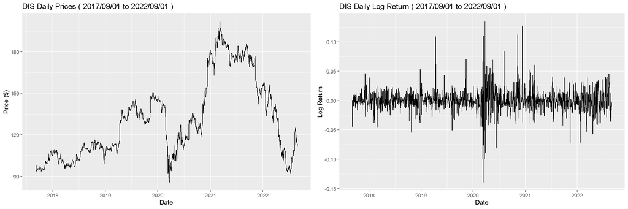

```r
# Specify ticker, start and end dates
ticker = 'DIS'
start_date = '2017/09/01'
end_date = '2022/09/01'

# Store price data as its symbol
dis_px <- getSymbols('DIS', src = 'yahoo', from = start_date, to = end_date)
# Use Adjusted price column
dis_px <- reduce(map(ticker, function(x) Ad(get(x))), merge)
# Change column name to ticker symbol
colnames(dis_px) <- gsub('\\..*','',colnames(dis_px))
# Compute log return for asset
dis_lr <- na.omit(diff(log(dis_px)))

# Plot time series price data
dis_px_plt <- qplot(index(dis_px), dis_px, ylab='Price ($)', xlab='Date', main= paste(ticker, 'Daily Prices', '(', start_date, 'to', end_date, ')'), geom = 'line')
# Plot time series log return data
dis_lr_plt <- qplot(index(dis_lr), dis_lr, ylab="Log Return", xlab="Date", main= paste(ticker, 'Daily Log Return', '(', start_date, 'to', end_date, ')'), geom = 'line')
# Arrange the two plots side-by-side
grid.arrange(dis_px_plt, dis_lr_plt, ncol=2)
```

We use the Augmented Dickey-Fuller (ADF), Phillips–Perro (PP), and KPSS tests to test for the log return stationarity. In the ADF and PP tests, we reject the The null hypotheses that the series is not stationary at a 5% significance level (p-value = 0.01 < 0.05), and conclude that Disney’s daily log return is stationary. In the KPSS test, we fail to reject the The null hypotheses that the series is stationary at a 5% significance level (p-value = 0.1 > 0.05), and conclude that Disney’s daily log return is stationary. All 3 tests confirm that Disney’s daily log return is stationary.

```r
# Augmented Dickey-Fuller Test
adf.test(dis_lr)
```

```
##
##  Augmented Dickey-Fuller Test
##
## data:  dis_lr
## Dickey-Fuller = -9.7268, Lag order = 10, p-value = 0.01
## alternative hypothesis: stationary
```

```r
# Phillips–Perron Test
pp.test(dis_lr)
```

```
##
##  Phillips-Perron Unit Root Test
##
## data:  dis_lr
## Dickey-Fuller Z(alpha) = -1408.2, Truncation lag parameter = 7, p-value
## = 0.01
## alternative hypothesis: stationary
```

```r
# KPSS Test
kpss.test(dis_lr)
```

```
##
##  KPSS Test for Level Stationarity
##
## data:  dis_lr
## KPSS Level = 0.17499, Truncation lag parameter = 7, p-value = 0.1
```

We use the `auto.arima()` function to select the optimal $p$, the number of lags for lookback in our AR(p) model. The function suggests one model that minimizes the AIC score and another model that minimizes the BIC score. The model that minimizes the AIC score is $Y_{t}=-0.0943Y_{t-1}+\epsilon_{t}$, an AR(1) process, and the one that minimizes the BIC score turns out to be the same model. Here, $\phi_{1}$ is estimated to be -0.0943 in the AR(1) model. This nonzero coefficient means that there is some information in today’s log return that could be used for prediction of tomorrow’s log return, but the small value of $\phi_{1}$ means that the prediction will not be very accurate. So, the potential for profit might be negated by trading costs. Also, according to properties of AR(1), since |-0.0943|= 0.0943 < 1, the process is stationary.

We set `d = 0` and `max.q = 0` because ARIMA(p,0,0) is equivalent to an AR(p) model. We will speak about the implementation of other models using ARIMA(p,d,q) configurations later.

We set `stepwise = FALSE` so that the algorithm searches over all models for the best one instead of just stopping after a few searches. We set `approximation = FALSE` so that the true values of AIC and BIC are used instead of their approximated values. If you are analyzing just one time series, and can afford to take some more time, it is recommended that you use these settings. Otherwise, use the default arguments to set them to TRUE.

```r
# Select AR(p) model based on AIC
dis_lr_ar_aic_fit = auto.arima(dis_lr, d = 0, max.q = 0, stepwise = FALSE, approximation = FALSE, ic = 'aic')
# Select AR(p) model based on BIC
dis_lr_ar_bic_fit = auto.arima(dis_lr, d = 0, max.q = 0, stepwise = FALSE, approximation = FALSE, ic = 'bic')
```

This is the model selected by minimizing the AIC score.

```r
# Return the selected model based on AIC
dis_lr_ar_aic_fit
```

```
## Series: dis_lr
## ARIMA(1,0,0) with zero mean
##
## Coefficients:
##           ar1
##       -0.0943
## s.e.   0.0281
##
## sigma^2 = 0.000378:  log likelihood = 3169.8
## AIC=-6335.59   AICc=-6335.58   BIC=-6325.32
```

This is the model selected by minimizing the BIC score.

```r
# Return the selected model based on BIC
dis_lr_ar_bic_fit
```

```
## Series: dis_lr
## ARIMA(1,0,0) with zero mean
##
## Coefficients:
##           ar1
##       -0.0943
## s.e.   0.0281
##
## sigma^2 = 0.000378:  log likelihood = 3169.8
## AIC=-6335.59   AICc=-6335.58   BIC=-6325.32
```

We move on to residual diagnostics. We call the `tsdiag()` function on chosen fitted AR(1) model. Remember, both AIC and BIC scores agrees on the same model so it doesn’t matter if we choose `dis_lr_aic_fit` or `dis_lr_bic_fit`. The diagnostic function produces 3 plots.

Second is the ACF, which shows that 3 autocorrelations fall outside of the band at lag 6, 7, and 8. Hence, the series is not White Noise.

Third is the plot for the p-values from the LJung-Box test, where the p-values are all significant (<0.05) for lags greater than 6, meaning the series is not White Noise.

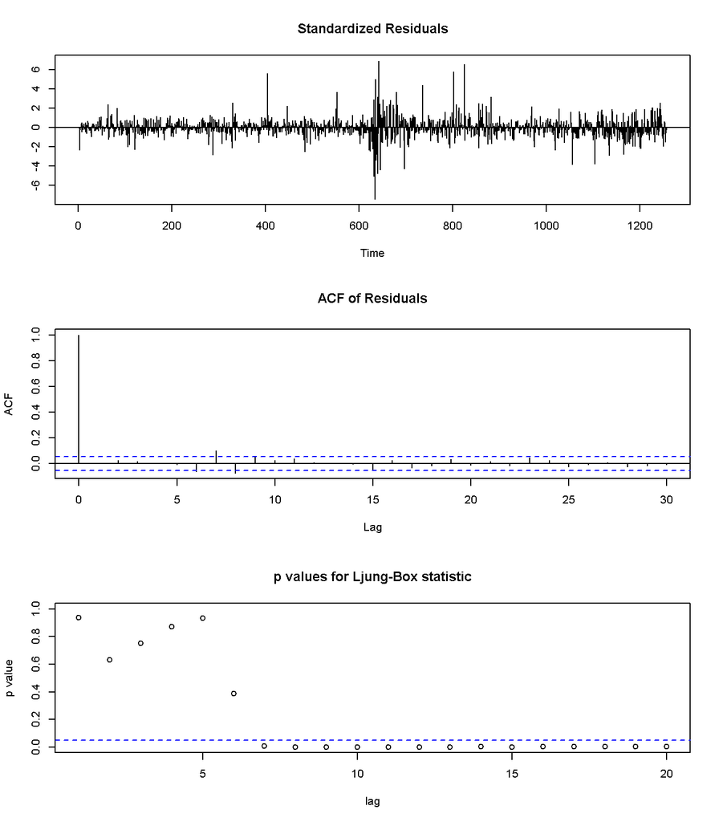

```r
# Output residual diagnostics of the selected model
tsdiag(dis_lr_ar_aic_fit, gof.lag = 20)
```

In addition, we plot a QQ plot to compare the AR(1) residual distribution with normal distribution quantiles. We observe that both the left and right tails of residuals are heavier than normal. This means that the AR(1) residuals follow a distribution with heavier extreme values, like the Student-t distribution.

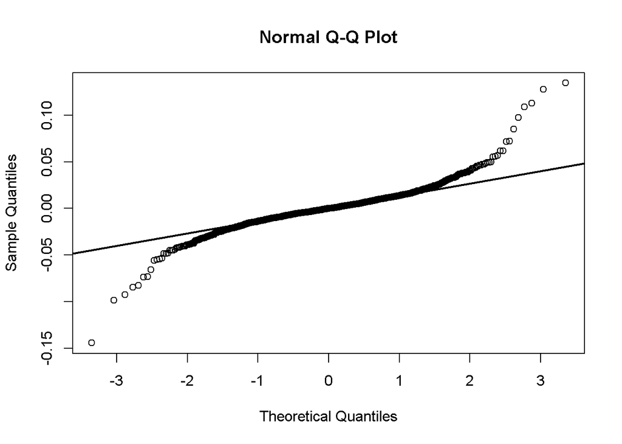

```r
# QQ plot of model residuals
qqnorm(dis_lr_ar_aic_fit$residuals)
qqline(dis_lr_ar_aic_fit$residuals, col = "black", lwd = 2)
```

We conclude that the AR(1) model is not adequate for fitting Disney’s daily stock log returns because residuals diagnostics do not provide evidence of White Noise. This model can be improved despite its parsimonious nature.

## Exercise #2: MA(q) on Disney’s Stock

We apply the `auto.arima()` function to select the optimal $q$, the number of lags for lookback in our MA(q) model. This function suggests MA(1) to be the best model that minimizes both the AIC score and BIC scores. The model takes on the mathematical form $Y_{t}=-0.0887\epsilon_{t-1}+\epsilon_{t}$. Here, $\theta_{1}$ is estimated to be -0.0887 in the MA(1) model. This nonzero coefficient means that there is some information in today’s external market information that could be used for prediction of tomorrow’s log return, but the small value of $\theta_{1}$ means that the prediction will not be very accurate. So, the potential for profit might be negated by trading costs.

We set `max.p = 0` and `d = 0` because ARIMA(0,0,q) is equivalent to an MA(q) model. We will speak about the implementation of other models using ARIMA(p,d,q) configurations later.

Again, we set `stepwise = FALSE` so that the algorithm searches over all models for the best one instead of just stopping after a few searches. We set `approximation = FALSE` so that the true values of AIC and BIC are used instead of their approximated values. It is recommended that you use these settings if you are analyzing just one time series, and can afford taking some more time. Otherwise, use the default arguments to set them to TRUE.

```r
# Select MA(q) model based on AIC
dis_lr_ma_aic_fit = auto.arima(dis_lr, max.p = 0, d = 0, stepwise = FALSE, approximation = FALSE, ic = 'aic')
# Select MA(q) model based on BIC
dis_lr_ma_bic_fit = auto.arima(dis_lr, max.p = 0, d = 0, stepwise = FALSE, approximation = FALSE, ic = 'bic')
```

This is the model selected by minimizing the AIC score.

```r
# Return the selected model based on AIC
dis_lr_ma_aic_fit
```

```
## Series: dis_lr
## ARIMA(0,0,1) with zero mean
##
## Coefficients:
##           ma1
##       -0.0887
## s.e.   0.0271
##
## sigma^2 = 0.0003782:  log likelihood = 3169.47
## AIC=-6334.93   AICc=-6334.92   BIC=-6324.66
```

This is the model selected by minimizing the BIC score.

```r
# Return the selected model based on BIC
dis_lr_ma_bic_fit
```

```
## Series: dis_lr
## ARIMA(0,0,1) with zero mean
##
## Coefficients:
##           ma1
##       -0.0887
## s.e.   0.0271
##
## sigma^2 = 0.0003782:  log likelihood = 3169.47
## AIC=-6334.93   AICc=-6334.92   BIC=-6324.66
```

From the ACF plot, we observe that 3 autocorrelations fall outside of the band at lag 6, 7, and 8. Hence, the series is not White Noise.

From the plot of LJung-Box test p-values, the p-values are all significant (<0.05) for lags greater than 6, meaning the series is not White Noise.

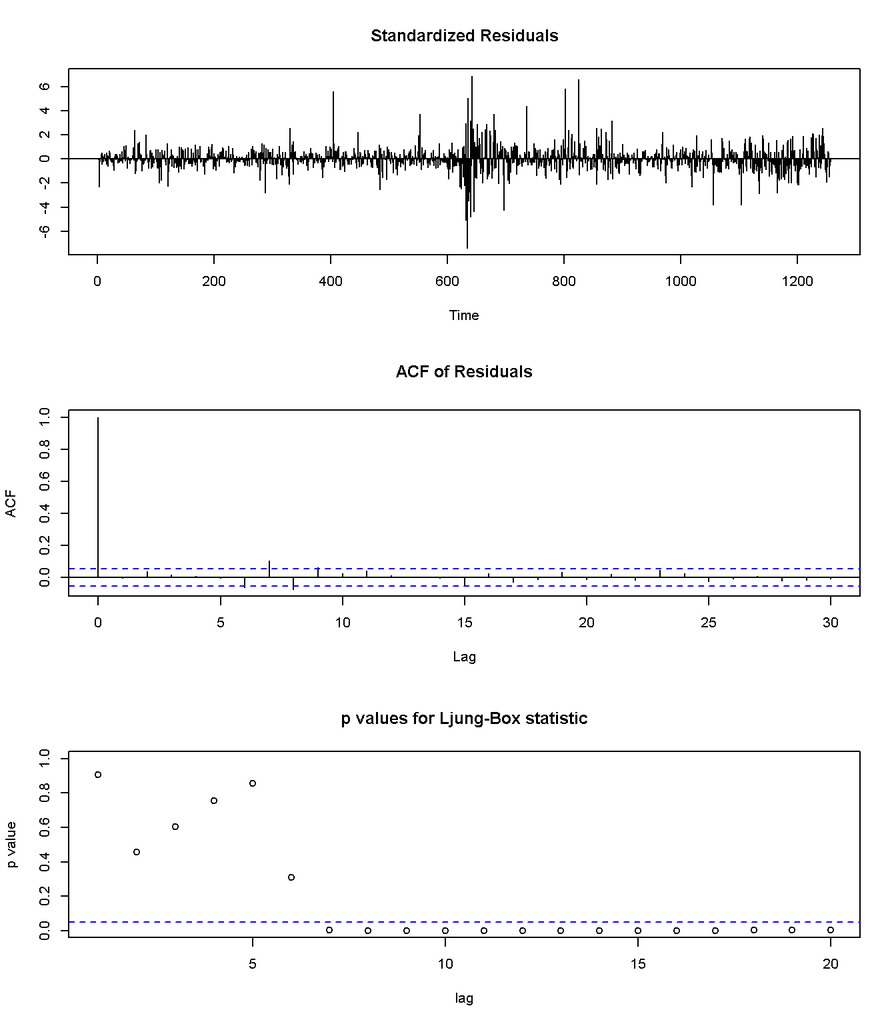

```r
# Output residual diagnostics of the selected model
tsdiag(dis_lr_ma_aic_fit, gof.lag = 20)
```

From the QQ plot, we compare the MA(1) residual distribution with normal distribution quantiles. We observe that both the left and right tails of residuals are heavier than normal. This means that the MA(1) residuals follow a distribution with heavier extreme values, like the Student-t distribution.

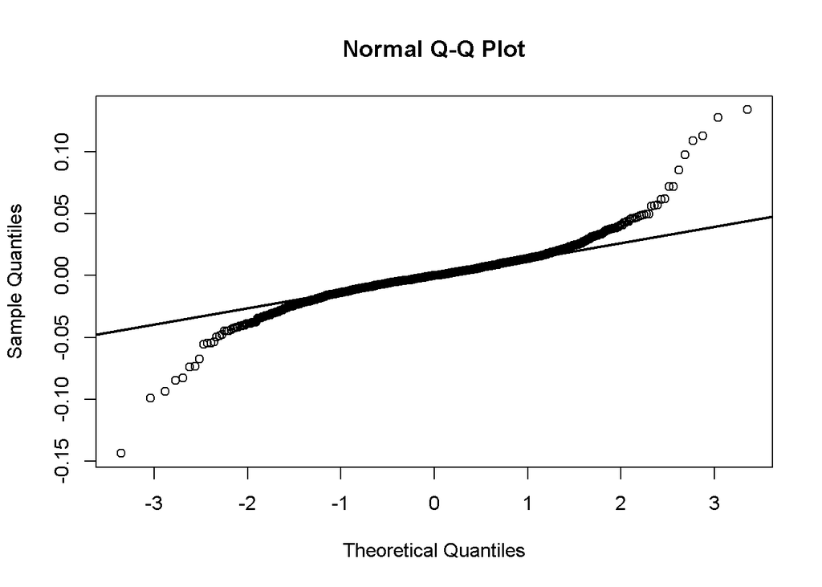

```r
# QQ plot of model residuals
qqnorm(dis_lr_ma_aic_fit$residuals)
qqline(dis_lr_ma_aic_fit$residuals, col = "black", lwd = 2)
```

We conclude that the performance of the MA(1) model is fairly similar to that of the AR(1) model above. It is not adequate for fitting Disney’s daily stock log returns because residuals diagnostics do not provide evidence of White Noise. This model is although parsimonious, can be enhanced.

## Exercise #3: ARIMA(p,d,q) on Disney’s Stock

We apply the `auto.arima()` function to select the optimal $p, d, q$ parameters in our ARIMA(p,d,q) model. This function suggests ARIMA(1,0,0) to be the best model that minimizes both the AIC score and BIC scores. This model is equivalent to the ARMA(1,0) and AR(1) processes. The model takes on the mathematical form $Y_{t}=-0.0943Y_{t-1}+\epsilon_{t}$. Other properties and implementations for the model are the same as what was described for the AR(1) model above.

```r
# Select AIMA(p,d,q) model based on AIC
dis_lr_arima_aic_fit = auto.arima(dis_lr, stepwise = FALSE, approximation = FALSE, ic = 'aic')
# Select AIMA(p,d,q) model based on BIC
dis_lr_arima_aic_fit = auto.arima(dis_lr, stepwise = FALSE, approximation = FALSE, ic = 'bic')
```

This is the model selected by minimizing the AIC score.

```r
# Return the selected model based on AIC
dis_lr_arima_aic_fit
```

```
## Series: dis_lr
## ARIMA(1,0,0) with zero mean
##
## Coefficients:
##           ar1
##       -0.0943
## s.e.   0.0281
##
## sigma^2 = 0.000378:  log likelihood = 3169.8
## AIC=-6335.59   AICc=-6335.58   BIC=-6325.32
```

This is the model selected by minimizing the BIC score.

```r
# Return the selected model based on BIC
dis_lr_arima_aic_fit
```

```
## Series: dis_lr
## ARIMA(1,0,0) with zero mean
##
## Coefficients:
##           ar1
##       -0.0943
## s.e.   0.0281
##
## sigma^2 = 0.000378:  log likelihood = 3169.8
## AIC=-6335.59   AICc=-6335.58   BIC=-6325.32
```

Residual diagnostics from the ARIMA(1,0,0) model are concluded in the same way as that for the AR(1) model above. In other words, we do not consider the model residuals as a White Noise process.

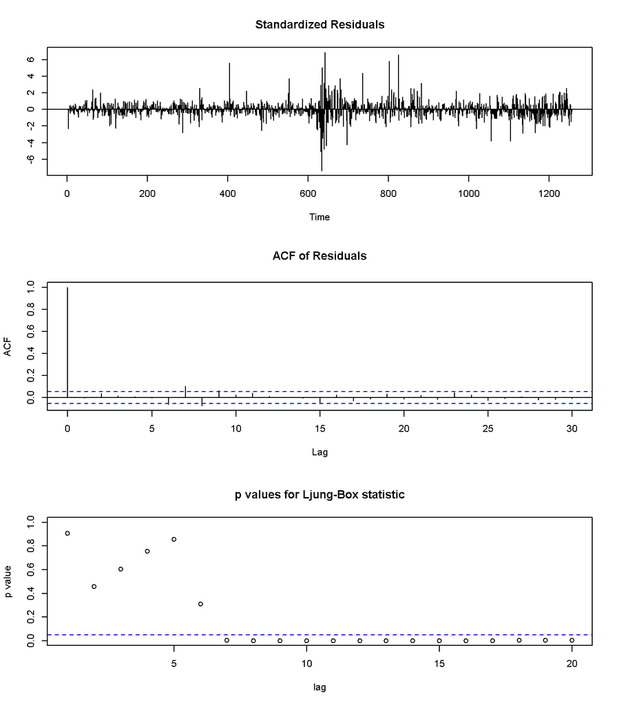

```r
# Output residual diagnostics of the selected model
tsdiag(dis_lr_ma_aic_fit, gof.lag = 20)
```

QQ plot of the ARIMA(1,0,0) residuals, again, shows heavier-than-normal tail values that can be modeled with thicker-tailed distributions such as the Student-t distribution.

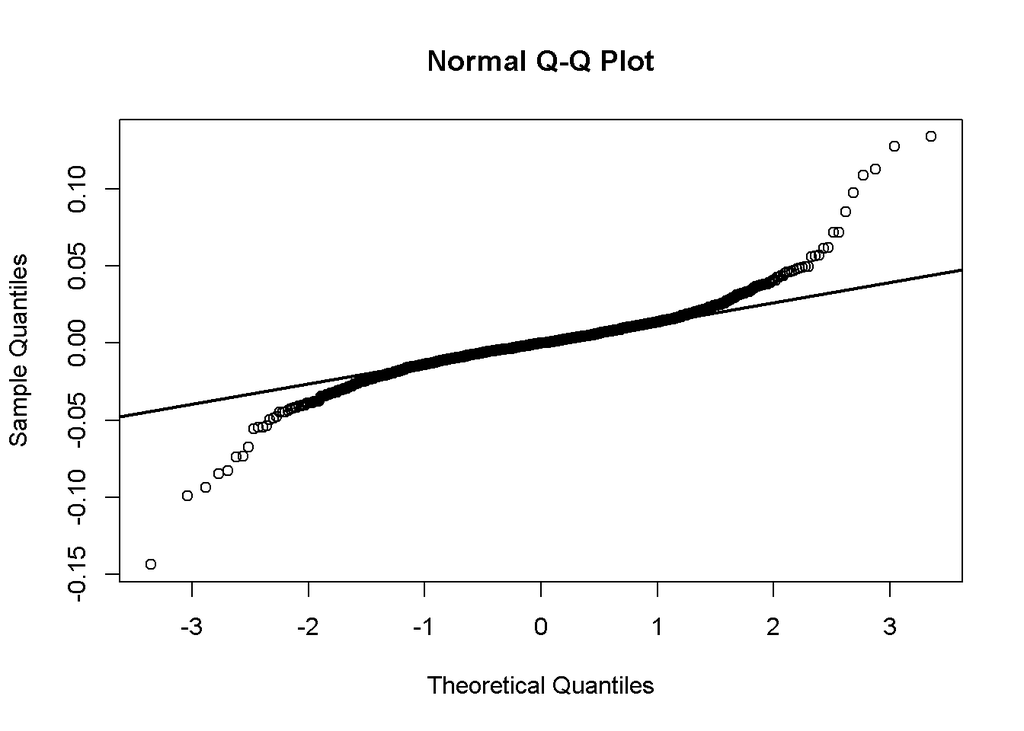

```r
# QQ plot of model residuals
qqnorm(dis_lr_ma_aic_fit$residuals)
qqline(dis_lr_ma_aic_fit$residuals, col = "black", lwd = 2)
```

We draw the same conclusion for both the ARIMA(1,0,0) and AR(1) models, that they are not adequate for fitting Disney’s daily stock log returns because residuals diagnostics do not provide evidence of White Noise. These models, although parsimonious, can be enhanced.

## Exercise #4: ARCH(p) on Disney’s Stock

In reality, the stock market is observed to have a time-varying volatility rather than a constant one. To account for this phenomenon, an ARCH(p) process is performed on Disney’s daily stock log returns.

We use the `garch()` function to configure ARCH models. We will see later that the ARCH(p) model is the reduced version of the GARCH(p,q) model.

### Try ARCH(1)…

We start by fitting an ARCH(1) model. We obtain the model by setting `order = c(0,1)` as 0 corresponds to the GARCH part and 1 corresponds to the ARCH part. We leave `coef = NULL` for the algorithm to estimate the coefficients; `itmax = 200` allows the log-likelihood function to evaluate up to 200 times when estimating coefficients; `eps = NULL` for the algorithm to estimate the $\{\epsilon_t\}$; `trace = FALSE` prevents all models fitted to be printed.

From the residual statistics, the median residual is around 0, which is a reasonable value for daily stock log returns. The maximum residual value is 8.04057 and the minimum residual value is -5.63257, meaning that there is a lack of symmetry around 0; specifically the residuals distribution is right-skewed.

From the coefficient estimates, p-value < 0.05, meaning that the $Y_{t-1}^2$ is significant in explaining model volatility.

From the Jarque-Bera Test, we see p-value < 0.05 and conclude that residuals are not normally distributed. However, keep in mind that because our sample size is large (1257), the data tends to prove most models wrong, so we can expect the null hypothesis of normal residuals to always be rejected. Hence, we need to also check the QQ plot for the residual tails.

```r
# Try ARCH(1) model
dis_lr_arch1_fit <- garch(dis_lr, order = c(0,1), coef = NULL,
itmax = 200, eps = NULL, trace = FALSE)

# Model summary
summary(dis_lr_arch1_fit)
```

```
##
## Call:
## garch(x = dis_lr, order = c(0, 1), coef = NULL, itmax = 200,     eps = NULL, trace = FALSE)
##
## Model:
## GARCH(0,1)
##
## Residuals:
##      Min       1Q   Median       3Q      Max
## -5.63257 -0.47404 -0.00168  0.48104  8.04057
##
## Coefficient(s):
##     Estimate  Std. Error  t value Pr(>|t|)
## a0 0.0002787   0.0000048   58.058   <2e-16 ***
## a1 0.2650627   0.0287564    9.218   <2e-16 ***
## ---
## Signif. codes:  0 '***' 0.001 '**' 0.01 '*' 0.05 '.' 0.1 ' ' 1
##
## Diagnostic Tests:
##  Jarque Bera Test
##
## data:  Residuals
## X-squared = 6213.2, df = 2, p-value < 2.2e-16
##
##
##  Box-Ljung test
##
## data:  Squared.Residuals
## X-squared = 0.32516, df = 1, p-value = 0.5685
```

We plot a time plot to observe the evolution of residuals. The series seems to revert to the mean around 0 but has a non-constant variance. These variations seem to be recurrent and are likely not due to outliers. Hence, we conclude that the residuals are nonstationary, and in turn, not a White Noise.

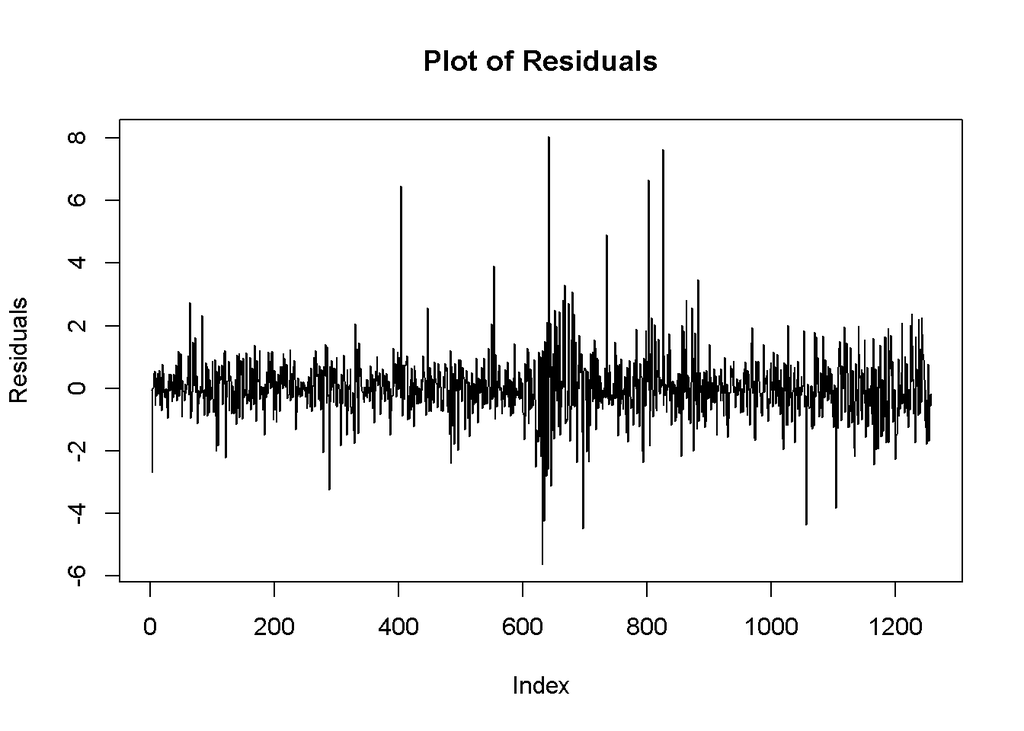

```r
# Time plot of model residuals
plot(dis_lr_arch1_fit$residuals,main='Plot of Residuals', ylab = 'Residuals',type="l")
```

The QQ plot shows that the left and right tails of the residuals are heavier than those of a normal distribution, which suggests that both tails are not well-modeled by a normal distribution. On top of the Jerque-Bera Test, it is safe to conclude that residuals are not normally distributed.

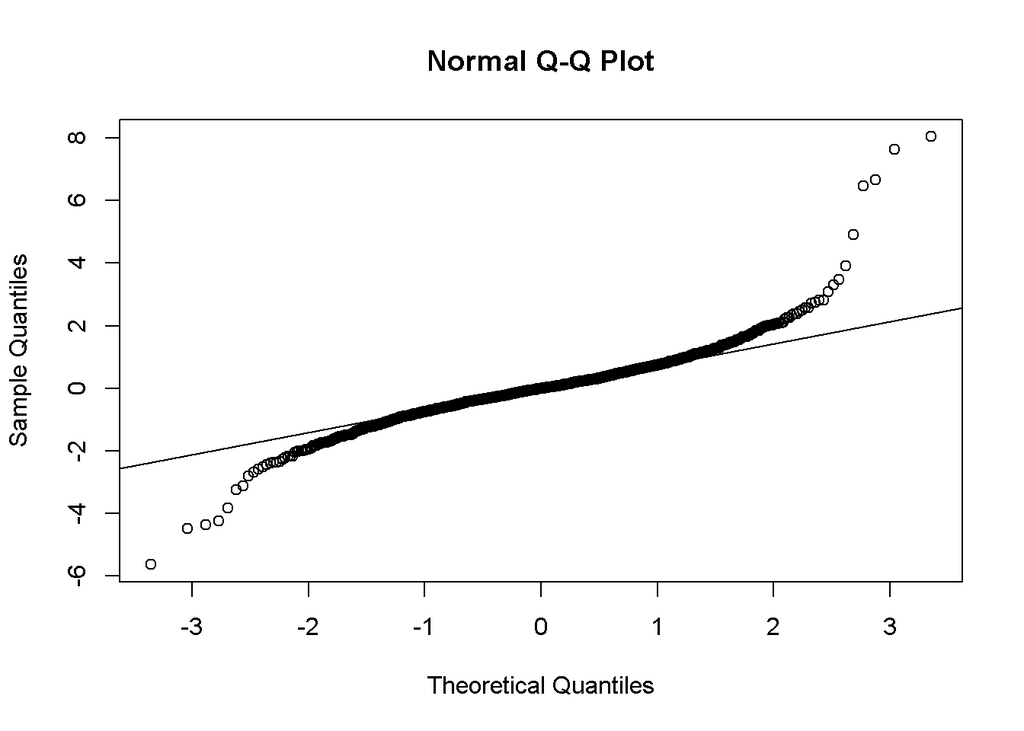

```r
# QQ plot of model residuals
qqnorm(dis_lr_arch1_fit$residuals)
qqline(dis_lr_arch1_fit$residuals)
```

In the histogram below, we see some extreme values of the residuals on the left tail up to around -6, and some occurrences of this on the right tail up to around 8. There is some skewness towards the right, leading to some asymmetry of the residuals distribution. This is another evidence of heavier tails, particularly on the right side, compared to a normal distribution. We set `breaks = 50` so that the range of residual values are broken down by 50 bars. You may increase this value to get more granular frequency breakdowns of the residuals.

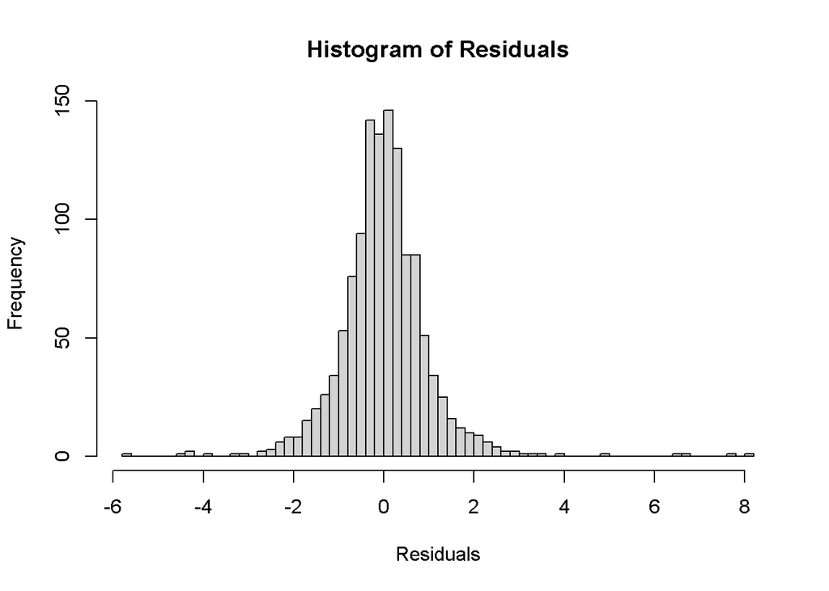

```r
# Histogram of model residuals
hist(dis_lr_arch1_fit$residuals, breaks = 50, main="Histogram of Residuals", xlab = 'Residuals')
```

The ACF plot suggests the squared residuals to be significantly correlated at lags 2, 3, 8, 11, and 23 at a 0.05 level. There are more than 2 significant autocorrelations so the squared residuals are correlated. This isn’t verified in the LJung-Box Test above.

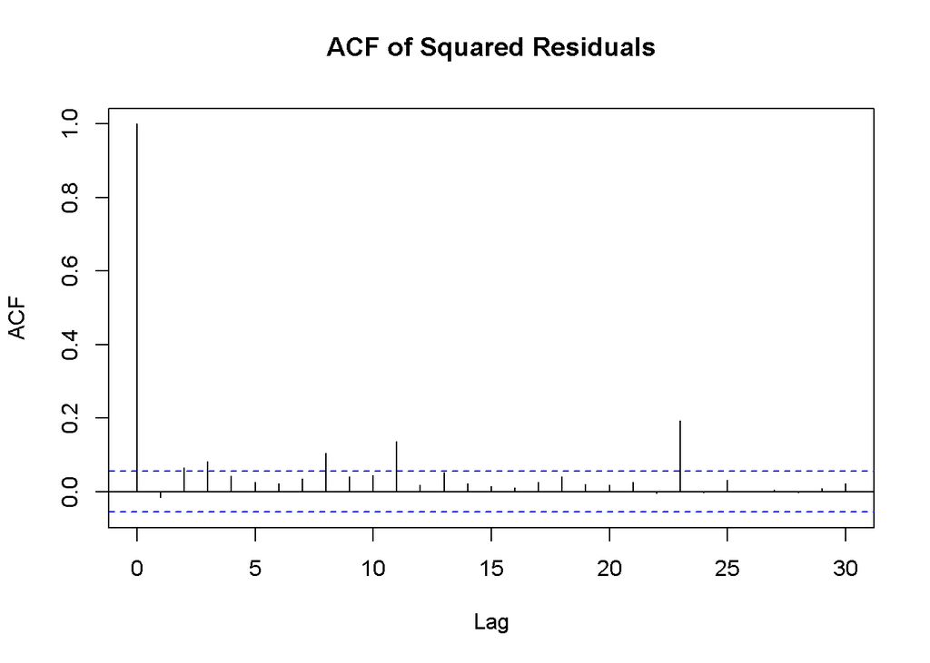

```r
# ACF of model residuals
n = length(dis_lr_arch1_fit$residuals)
acf((dis_lr_arch1_fit$residuals[2:n])^2, main = "ACF of Squared Residuals")
```

We conclude that the ARCH(1) model is not adequate for fitting Disney’s daily stock log returns because, firstly, residuals are not White Noise due to non-constant variance; secondly, they are not normally distributed because of their skewness and heavy tails; and thirdly, the squared residuals are correlated.

### Try ARCH(2)…

Let’s try fitting an ARCH(2) model. We will keep the `garch()` configurations the same except for setting `order = c(0,2)` as 2 corresponds to the `p` parameter in the ARCH(p) model.

From the residual statistics, the median residual is exactly 0, which is an optimal value. The maximum residual value is 8.5201 and the minimum residual value is -4.6852, meaning that there is a lack of symmetry around 0; specifically the residuals is expected to be right-skewed.

From the coefficient estimates, all p-values < 0.05, meaning that the $Y_{t-1}^2$ and $Y_{t-2}^2$ are significant in explaining model volatility.

From the Jarque-Bera Test, we see p-value < 0.05 and conclude that residuals are not normally distributed. However, since we have a large data, we can expect to always get our null hypothesis rejected. Because of this, we need to also check the QQ plot for the residual tails.

From the LJung-Box Test, we see p-value > 0.05 and conclude that squared residuals are not correlated. This can also be verified through the ACF plot below.

```r
# Try ARCH(2) model
dis_lr_arch2_fit <- garch(dis_lr, order = c(0,2), coef = NULL,
itmax = 200, eps = NULL, trace = FALSE)

# Model summary
summary(dis_lr_arch2_fit)
```

```
##
## Call:
## garch(x = dis_lr, order = c(0, 2), coef = NULL, itmax = 200,     eps = NULL, trace = FALSE)
##
## Model:
## GARCH(0,2)
##
## Residuals:
##     Min      1Q  Median      3Q     Max
## -4.6852 -0.4913  0.0000  0.5092  8.5201
##
## Coefficient(s):
##     Estimate  Std. Error  t value Pr(>|t|)
## a0 2.181e-04   4.456e-06   48.950  < 2e-16 ***
## a1 1.788e-01   3.367e-02    5.310 1.10e-07 ***
## a2 2.452e-01   2.966e-02    8.266 2.22e-16 ***
## ---
## Signif. codes:  0 '***' 0.001 '**' 0.01 '*' 0.05 '.' 0.1 ' ' 1
##
## Diagnostic Tests:
##  Jarque Bera Test
##
## data:  Residuals
## X-squared = 5005.6, df = 2, p-value < 2.2e-16
##
##
##  Box-Ljung test
##
## data:  Squared.Residuals
## X-squared = 0.24702, df = 1, p-value = 0.6192
```

We plot a time plot to observe the evolution of residuals. The series seems to revert to the mean around 0 and has some non-constant variance. Therefore, the residuals are nonstationary, and in turn, not a White Noise.

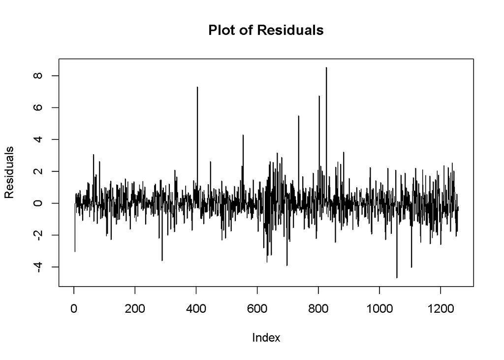

```r
# Time plot of model residuals
plot(dis_lr_arch2_fit$residuals,main='Plot of Residuals', ylab = 'Residuals',type="l")
```

The QQ plot shows that the left and right tails of the residuals are heavier than those of a normal distribution, which suggests that both tails are not well-modeled by a normal distribution. On top of the Jerque-Bera Test, it is safe to conclude that residuals are not normally distribute.

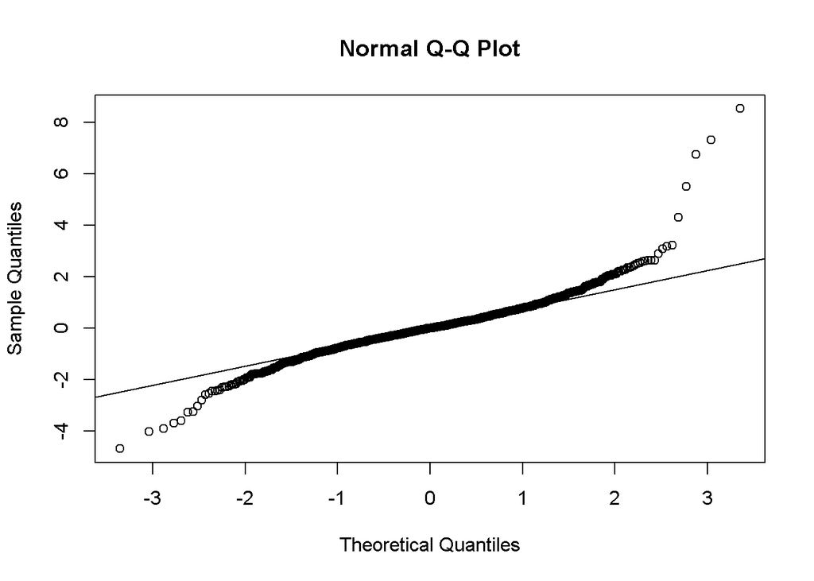

```r
# QQ plot of model residuals
qqnorm(dis_lr_arch2_fit$residuals)
qqline(dis_lr_arch2_fit$residuals)
```

In the histogram below, we see some extreme values of the residuals on the left tail up to around -5, and some occurrences of this on the right tail up to around 8. There is a more obvious skewness towards the right, which guides the asymmetry of the residuals distribution. This is another evidence of heavier tails, particularly on the right side, compared to a normal distribution.

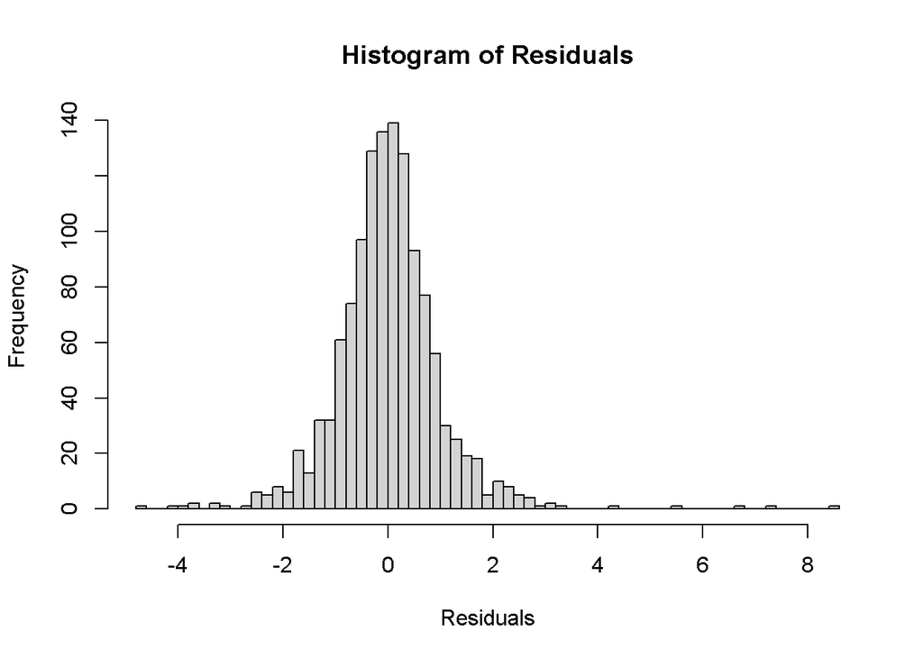

```r
# Histogram of model residuals
hist(dis_lr_arch2_fit$residuals, breaks = 50, main="Histogram of Residuals", xlab = 'Residuals')
```

The ACF plot suggests the squared residuals to be significantly correlated at lag 23 at a 0.05 level. There are less than 2 significant autocorrelations so the squared residuals are not correlated. This can also be verified in the LJung-Box Test above.

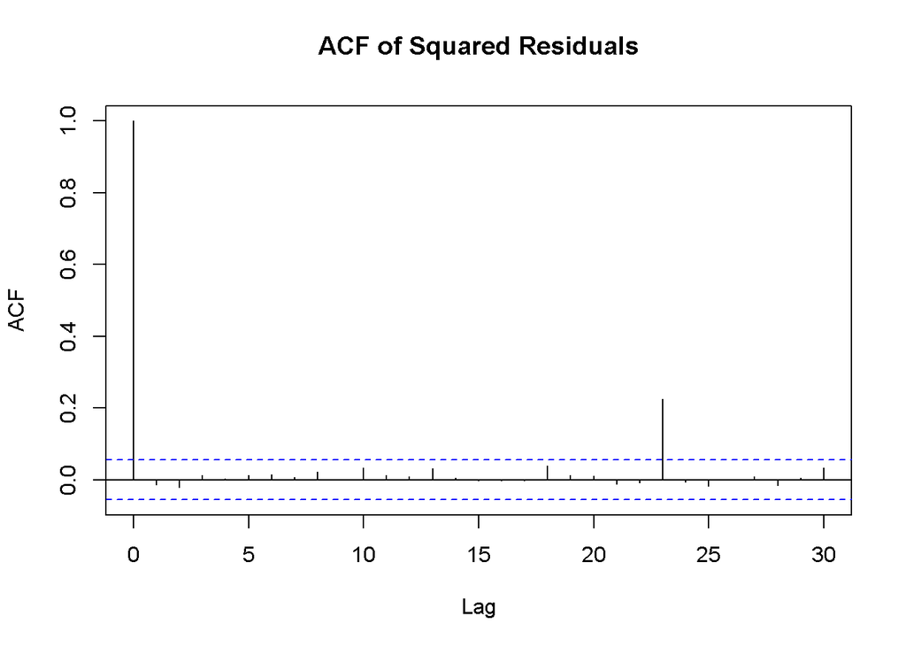

```r
# ACF of model residuals
n = length(dis_lr_arch2_fit$residuals)
acf((dis_lr_arch2_fit$residuals[3:n])^2, main = "ACF of Squared Residuals")
```

We conclude that the ARCH(2) model is not adequate for fitting Disney’s daily stock log returns because, firstly, residuals are not White Noise due to non-constant variance; secondly, they are not normally distributed because of their skewness and heavy tails

### Try ARCH(3)…

Let’s try fitting an ARCH(3) model. We will keep the `garch()` configurations the same except for setting `order = c(0,3)` as 3 corresponds to the `p` parameter in the ARCH(p) model.

From the residual statistics, the median residual is exactly 0, which is an optimal value. The maximum residual value is 8.8283 and the minimum residual value is -4.8156, meaning that there is a lack of symmetry around 0; specifically the residuals is expected to be right-skewed.

From the coefficient estimates, all p-values < 0.05, meaning that the $Y_{t-1}^2$, $Y_{t-2}^2$, and $Y_{t-3}^2$ are significant in explaining model volatility.

From the Jarque-Bera Test, we see p-value < 0.05 and conclude that residuals are not normally distributed. However, since we have a large data, we can expect to always get our null hypothesis rejected. Because of this, we need to also check the QQ plot for the residual tails.

From the LJung-Box Test, we see p-value > 0.05 and conclude that squared residuals are not correlated. This can also be verified through the ACF plot below.

```r
# Try ARCH(3) model
dis_lr_arch3_fit <- garch(dis_lr, order = c(0,3), coef = NULL,
itmax = 200, eps = NULL, trace = FALSE)

# Model summary
summary(dis_lr_arch3_fit)
```

```
##
## Call:
## garch(x = dis_lr, order = c(0, 3), coef = NULL, itmax = 200,     eps = NULL, trace = FALSE)
##
## Model:
## GARCH(0,3)
##
## Residuals:
##     Min      1Q  Median      3Q     Max
## -4.8156 -0.4980  0.0000  0.5081  8.8283
##
## Coefficient(s):
##     Estimate  Std. Error  t value Pr(>|t|)
## a0 2.034e-04   4.530e-06   44.903  < 2e-16 ***
## a1 1.362e-01   3.287e-02    4.145 3.40e-05 ***
## a2 2.198e-01   2.902e-02    7.573 3.64e-14 ***
## a3 9.587e-02   2.337e-02    4.102 4.10e-05 ***
## ---
## Signif. codes:  0 '***' 0.001 '**' 0.01 '*' 0.05 '.' 0.1 ' ' 1
##
## Diagnostic Tests:
##  Jarque Bera Test
##
## data:  Residuals
## X-squared = 5588.4, df = 2, p-value < 2.2e-16
##
##
##  Box-Ljung test
##
## data:  Squared.Residuals
## X-squared = 0.093658, df = 1, p-value = 0.7596
```

We plot a time plot to observe the evolution of residuals. The series seems to revert to the mean around 0 and has some non-constant variance. Therefore, the residuals are nonstationary, and in turn, not a White Noise.

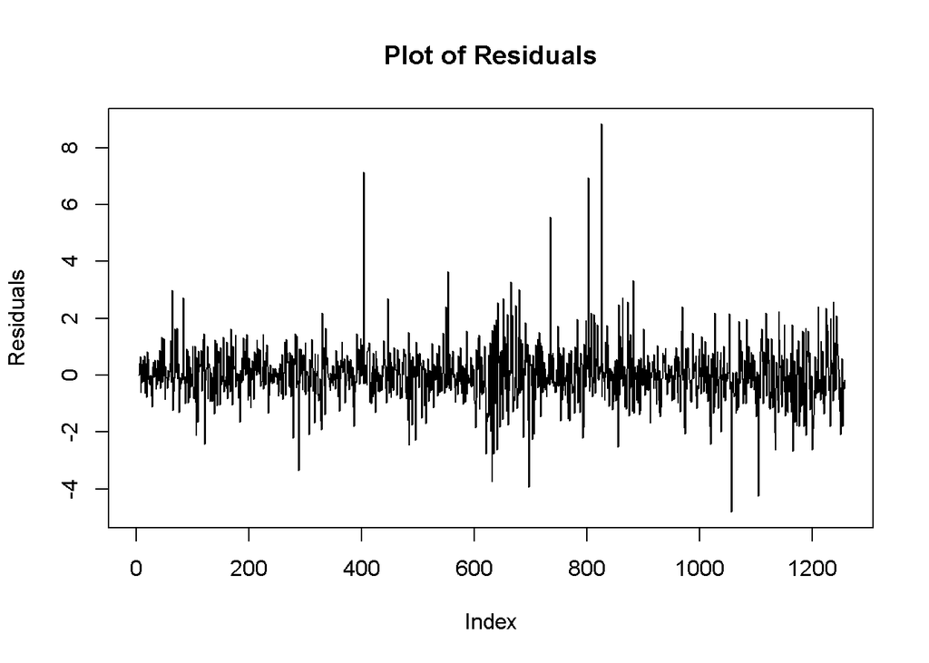

```r
# Time plot of model residuals
plot(dis_lr_arch3_fit$residuals,main='Plot of Residuals', ylab = 'Residuals',type="l")
```

The QQ plot shows that the left and right tails of the residuals are heavier than those of a normal distribution, which suggests that both tails are not well-modeled by a normal distribution. This adds to the conclusion from the Jerque-Bera Test that residuals are not normally distributed.

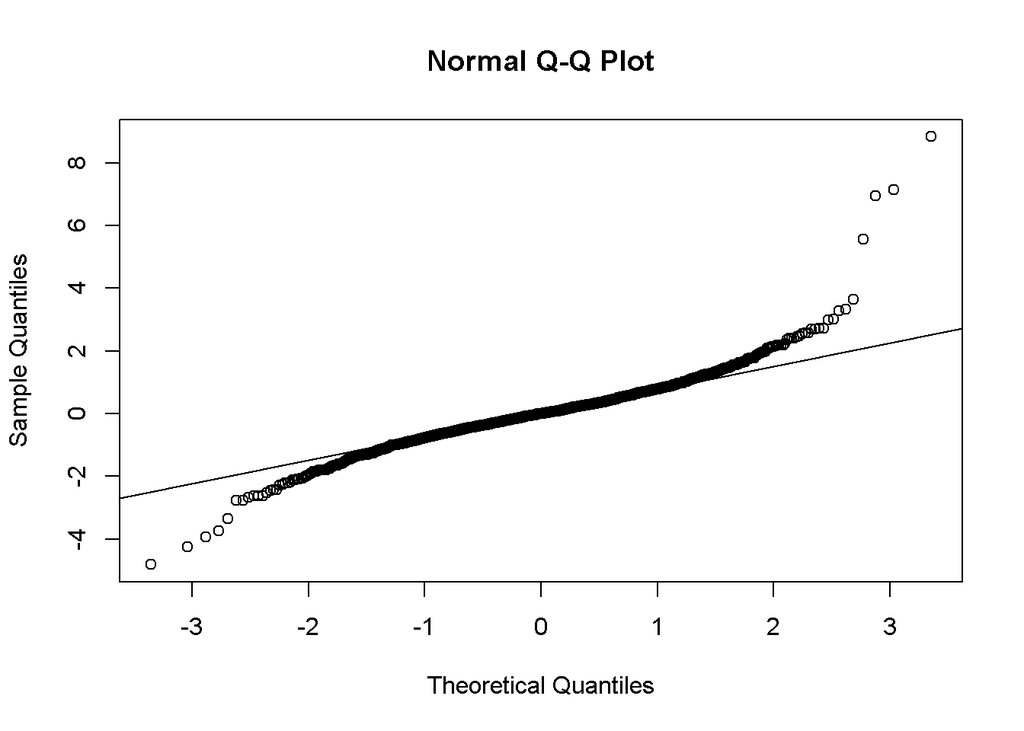

```r
# QQ plot of model residuals
qqnorm(dis_lr_arch3_fit$residuals)
qqline(dis_lr_arch3_fit$residuals)
```

In the histogram below, we see some extreme values of the residuals on the left tail up to around -5, and some occurrences of this on the right tail up to around 9. There is a more obvious skewness towards the right, which guides the asymmetry of the residuals distribution. This is another evidence of heavier tails, particularly on the right side, compared to a normal distribution.

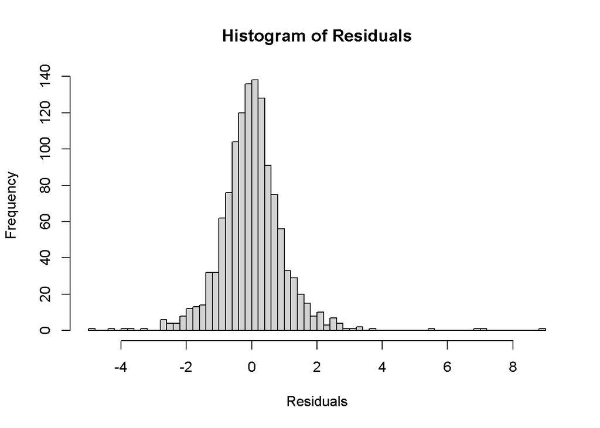

```r
# Histogram of model residuals
hist(dis_lr_arch3_fit$residuals, breaks = 50, main="Histogram of Residuals", xlab = 'Residuals')
```

The ACF plot suggests the squared residuals to be significantly correlated at lag 23 at a 0.05 level. There are less than 2 significant autocorrelations so the squared residuals are not correlated. This can also be verified in the LJung-Box Test above.

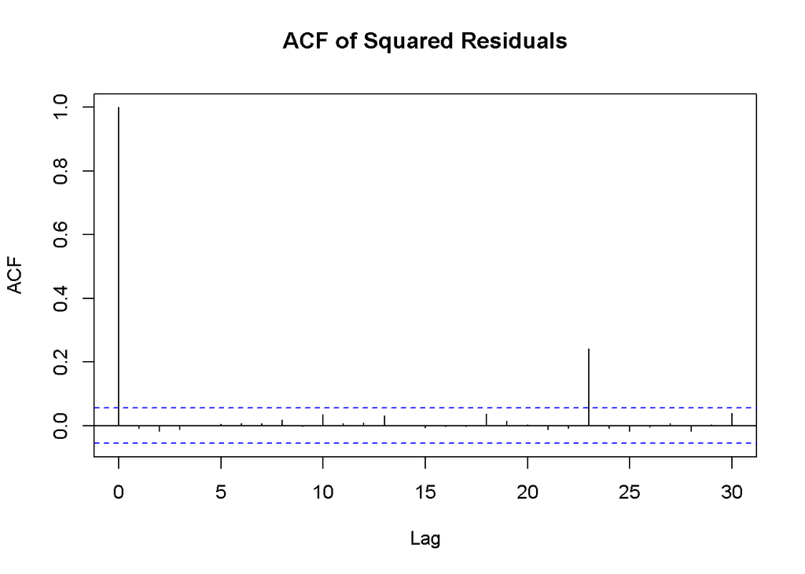

```r
# ACF of model residuals
n = length(dis_lr_arch3_fit$residuals)
acf((dis_lr_arch3_fit$residuals[4:n])^2, main = "ACF of Squared Residuals")
```

We conclude that the ARCH(3) model is not adequate for fitting Disney’s daily stock log returns because, firstly, residuals are not White Noise due to non-constant variance; secondly, they are not normally distributed because of their skewness and heavy tails

### Try ARCH(4)…

Let’s try fitting an ARCH(4) model. We will keep the `garch()` configurations the same except for setting `order = c(0,4)` as 4 corresponds to the `p` parameter in the ARCH(p) model.

From the residual statistics, the median residual is exactly 0, which is an optimal value. The maximum residual value is 9.1586 and the minimum residual value is -4.1974, meaning that there is a lack of symmetry around 0; specifically the residuals is expected to be right-skewed.

From the coefficient estimates, all p-values < 0.05, meaning that the $Y_{t-1}^2$, $Y_{t-2}^2$, $Y_{t-3}^2$, and $Y_{t-4}^2$ are significant in explaining model volatility.

From the Jarque-Bera Test, we see p-value < 0.05 and conclude that residuals are not normally distributed. However, since we have a large data, we can expect to always get our null hypothesis rejected. Because of this, we need to also check the QQ plot for the residual tails.

From the LJung-Box Test, we see p-value > 0.05 and conclude that squared residuals are not correlated. This can also be verified through the ACF plot below.

```r
# Try ARCH(4) model
dis_lr_arch4_fit <- garch(dis_lr, order = c(0,4), coef = NULL,
itmax = 200, eps = NULL, trace = FALSE)

# Model summary
summary(dis_lr_arch4_fit)
```

```
##
## Call:
## garch(x = dis_lr, order = c(0, 4), coef = NULL, itmax = 200,     eps = NULL, trace = FALSE)
##
## Model:
## GARCH(0,4)
##
## Residuals:
##     Min      1Q  Median      3Q     Max
## -4.1974 -0.5118  0.0000  0.4978  9.1586
##
## Coefficient(s):
##     Estimate  Std. Error  t value Pr(>|t|)
## a0 1.889e-04   4.166e-06   45.347  < 2e-16 ***
## a1 1.298e-01   3.353e-02    3.870 0.000109 ***
## a2 1.681e-01   2.999e-02    5.606 2.07e-08 ***
## a3 1.022e-01   2.259e-02    4.525 6.04e-06 ***
## a4 9.704e-02   1.669e-02    5.813 6.12e-09 ***
## ---
## Signif. codes:  0 '***' 0.001 '**' 0.01 '*' 0.05 '.' 0.1 ' ' 1
##
## Diagnostic Tests:
##  Jarque Bera Test
##
## data:  Residuals
## X-squared = 5968.1, df = 2, p-value < 2.2e-16
##
##
##  Box-Ljung test
##
## data:  Squared.Residuals
## X-squared = 0.07569, df = 1, p-value = 0.7832
```

We plot a time plot to observe the evolution of residuals. The series seems to revert to the mean around 0 and has some non-constant variance. Therefore, the residuals are nonstationary, and in turn, not a White Noise.

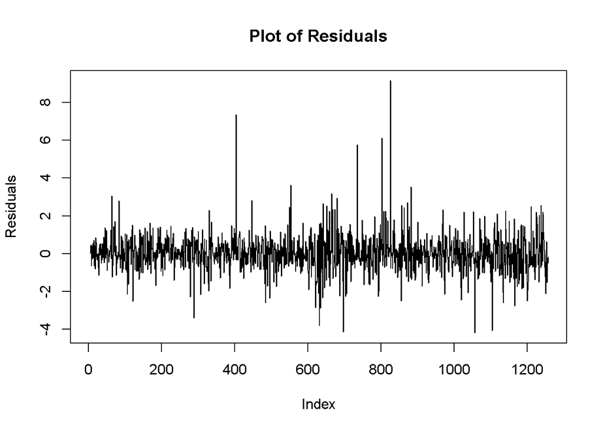

```r
# Time plot of model residuals
plot(dis_lr_arch4_fit$residuals,main='Plot of Residuals', ylab = 'Residuals',type="l")
```

The QQ plot shows that the left and right tails of the residuals are heavier than those of a normal distribution, which suggests that both tails are not well-modeled by a normal distribution. This adds to the conclusion from the Jerque-Bera Test that residuals are not normally distributed.

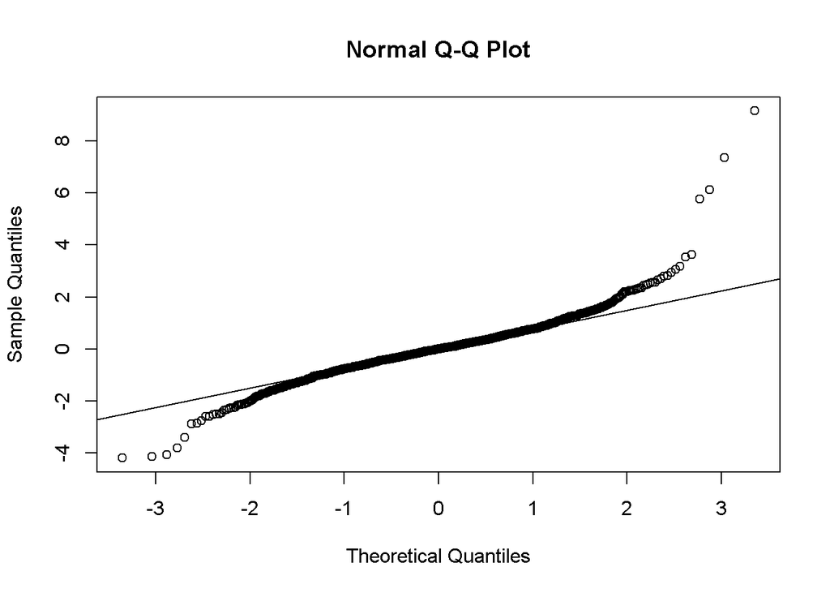

```r
# QQ plot of model residuals
qqnorm(dis_lr_arch4_fit$residuals)
qqline(dis_lr_arch4_fit$residuals)
```

In the histogram below, we see some extreme values of the residuals on the left tail up to around -4, and some occurrences of this on the right tail up to around 9. There is a more obvious skewness towards the right, which guides the asymmetry of the residuals distribution. This is another evidence of heavier tails, particularly on the right side, compared to a normal distribution.

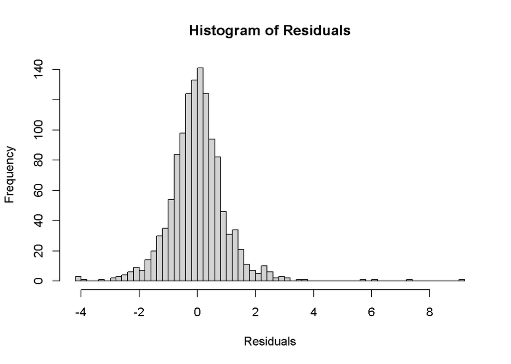

```r
# Histogram of model residuals
hist(dis_lr_arch4_fit$residuals, breaks = 50, main="Histogram of Residuals", xlab = 'Residuals')
```

The ACF plot suggests the squared residuals to be significantly correlated at lag 23 at a 0.05 level. There are less than 2 significant autocorrelations so the squared residuals are not correlated. This can also be verified in the LJung-Box Test above.

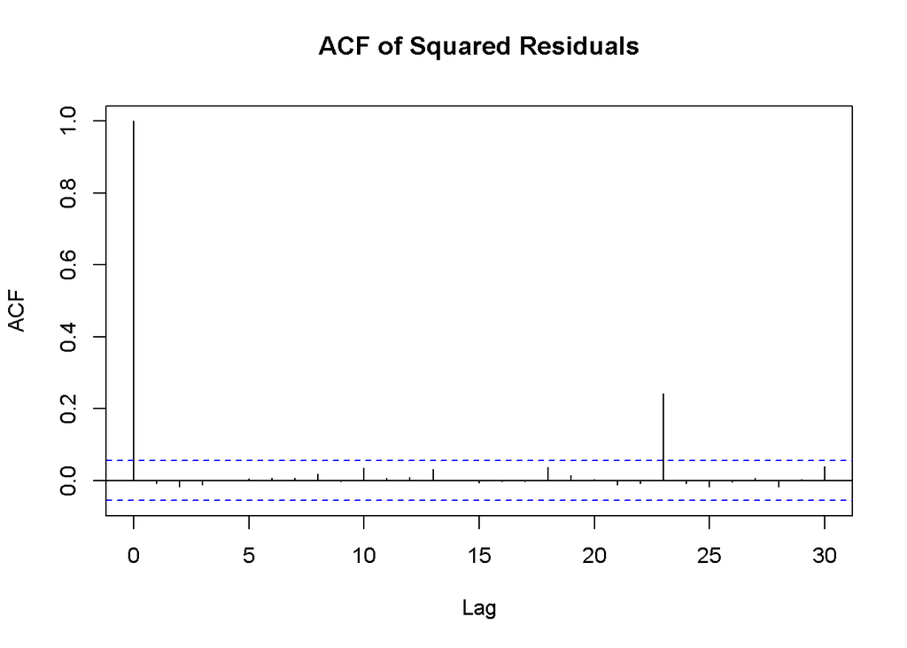

```r
# ACF of model residuals
n = length(dis_lr_arch4_fit$residuals)
acf((dis_lr_arch3_fit$residuals[4:n])^2, main = "ACF of Squared Residuals")
```

We conclude that the ARCH(4) model is not adequate for fitting Disney’s daily stock log returns because, firstly, residuals are not White Noise due to non-constant variance; secondly, they are not normally distributed because of their skewness and heavy tails

Overall, we fitted 4 ARCH(p) models on Disney’s daily stock log returns. The model performance improved from ARCH(1) to ARCH(2). Particularly, the squared residuals become uncorrelated. From ARCH(2) to ARCH(3), there is no major improvement as the residuals series is still not normally distributed and not a White Noise. From ARCH(3) to ARCH(4), the problem with residuals non-normality and nonstationarity still persists.

At this point, increasing p, will just complicate the model as little to no progress is being made on improving the residual distribution fits. We will see later that a GARCH(p,q) model can assume a heavier-tailed distribution on residuals, like a Student-t distribution, which will solve such problem.

## Exercise #5: GARCH(p,q) on Disney’s Stock

We expand the ARCH(p) model into a GARCH(p,q) model so that the errors/ residuals/ external information with a heavy tail can be modeled properly.

We use the `garchFit()` function to configure GARCH models. We will see later how we can also incorporate ARMA components in GARCH.

### Try GARCH(1,1) with Normal Innovations…

We start by fitting an GARCH(1,1) model with normal innovations. We obtain the model by setting `~garch(1,1)`. We set `cond.dist = c("norm")` to assume normal innovations. `include.mean = FALSE` directs the model to assume 0 mean, which is what we want; `algorithm = c("nlminb")` and `hessian = c("ropt")` are calculation and optimization methods for coefficient estimates in the model; `trace = FALSE` prevents all models fitted to be printed.

From the Error Analysis, the p-values for the coefficient estimates, $\alpha_1$ and $\beta_1$ are < 0.05, meaning that $Y_{t-1}^2$ and $\sigma_{t-1}^2$ are significant in explaining model volatility.

From the Standardized Residuals Tests, Jarque-Bera Test and Shapiro-Wilk Test both have p-values < 0.05, indicating that the standardized residuals are not normally distributed, although we assumed normal innovations here. However, keep in mind that because our sample size is large (1257), the data tends to prove most models wrong, so we can expect the null hypothesis of normal residuals to always be rejected. Hence, we need to also check the QQ plot for the residual tails. The first 3 Ljung Box Tests yield p-values > 0.05, implying that the standardized residuals are not correlated. The last 3 Ljung Box Tests yield p-values > 0.05, implying that the standardized squared residuals are not correlated. This can also be verified through the ACF plot below.

From the Information Criterion Statistics, BIC = -5.257137, which is higher than what’s calculated for the GARCH(1,1) model with Student-t innovations. This indicates that GARCH(1,1) with normal innovations doesn’t have the best goodness of fit.

```r
# Try GARCH(1,1) model with normal innovations
garch11_norm = garchFit(~garch(1,1), data= dis_lr,
cond.dist = c("norm"), include.mean = FALSE,
algorithm = c("nlminb"), hessian = c("ropt"),
trace = FALSE)

# Model summary
summary(garch11_norm)
```

```
##
## Title:
##  GARCH Modelling
##
## Call:
##  garchFit(formula = ~garch(1, 1), data = dis_lr, cond.dist = c("norm"),
##     include.mean = FALSE, trace = FALSE, algorithm = c("nlminb"),
##     hessian = c("ropt"))
##
## Mean and Variance Equation:
##  data ~ garch(1, 1)
## <environment: 0x00000000238f5610>
##  [data = dis_lr]
##
## Conditional Distribution:
##  norm
##
## Coefficient(s):
##      omega      alpha1       beta1
## 1.1721e-05  7.8197e-02  8.9132e-01
##
## Std. Errors:
##  based on Hessian
##
## Error Analysis:
##         Estimate  Std. Error  t value Pr(>|t|)
## omega  1.172e-05   3.020e-06    3.881 0.000104 ***
## alpha1 7.820e-02   1.449e-02    5.397 6.76e-08 ***
## beta1  8.913e-01   1.800e-02   49.515  < 2e-16 ***
## ---
## Signif. codes:  0 '***' 0.001 '**' 0.01 '*' 0.05 '.' 0.1 ' ' 1
##
## Log Likelihood:
##  3314.815    normalized:  2.637085
##
## Description:
##  Mon Nov 21 01:42:51 2022 by user: user
##
##
## Standardised Residuals Tests:
##                                 Statistic p-Value
##  Jarque-Bera Test   R    Chi^2  4001.608  0
##  Shapiro-Wilk Test  R    W      0.9224612 0
##  Ljung-Box Test     R    Q(10)  6.618911  0.7608653
##  Ljung-Box Test     R    Q(15)  10.08247  0.8145204
##  Ljung-Box Test     R    Q(20)  15.58741  0.7418683
##  Ljung-Box Test     R^2  Q(10)  1.371744  0.9992823
##  Ljung-Box Test     R^2  Q(15)  3.067229  0.9995387
##  Ljung-Box Test     R^2  Q(20)  5.180974  0.9996348
##  LM Arch Test       R    TR^2   1.797013  0.9996595
##
## Information Criterion Statistics:
##       AIC       BIC       SIC      HQIC
## -5.269396 -5.257137 -5.269407 -5.264788
```

The GARCH model stores the log return volatility estimates in `dis_lr_garch11_fit@sigma.t`. These are the estimated values of $\sigma_{t}, \sigma_{t-1}, ..., \sigma_{t-p}$ from the model. We plot a time plot of the volatility estimates overlaying the log return series and observe that the volatility estimates don’t capture the swings with large magnitudes very well, especially especially from 2019 to 2021.

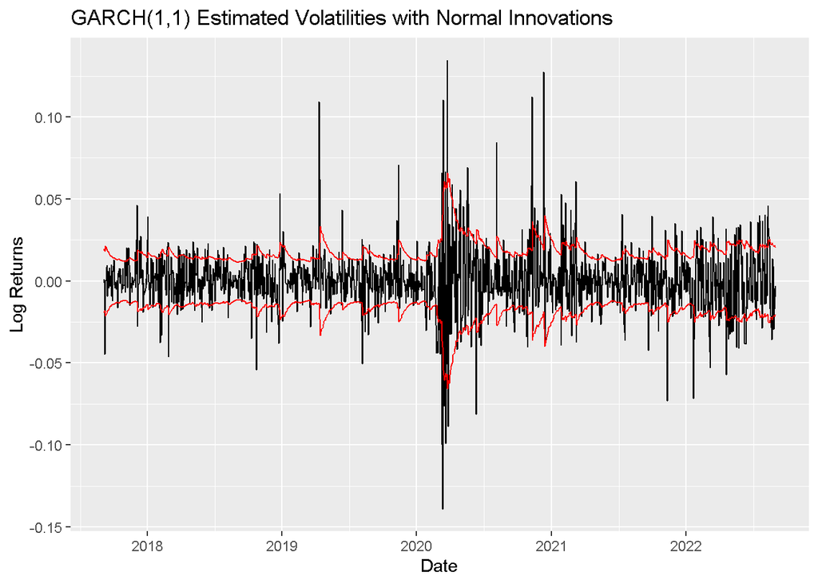

```r
# Estimated volatility values
garch11_norm_vol = garch11_norm@sigma.t

# Estimated volatility time plot
qplot(index(dis_lr), dis_lr, ylab="Log Returns", xlab="Date", main="GARCH(1,1) Estimated Volatilities with Normal Innovations", geom = "line")+geom_line(data = as.data.frame(garch11_norm_vol), aes(y=garch11_norm_vol), color = "red")+geom_line(data = as.data.frame(-garch11_norm_vol), aes(y=-garch11_norm_vol), color = "red")
```

The GARCH model also stores the estimated residuals in `dis_lr_garch11_fit@residuals`. These are the estimated values of $\epsilon_{t}, \epsilon_{t-1}, ..., \epsilon_{t-p}$ from the model. The standardized residuals (innovations) are calculated via the formula $\frac{\text{estimated residuals}}{\text{estimated volatility}}$, and is obtained through `dis_lr_garch11_fit@residuals/dis_lr_garch11_vol`. From the time plot of the standardized residuals, we see that the series is mean-reverting but has times when its variance are not constant. Therefore, the standardized residuals are nonstationary, and in turn, not a White Noise.

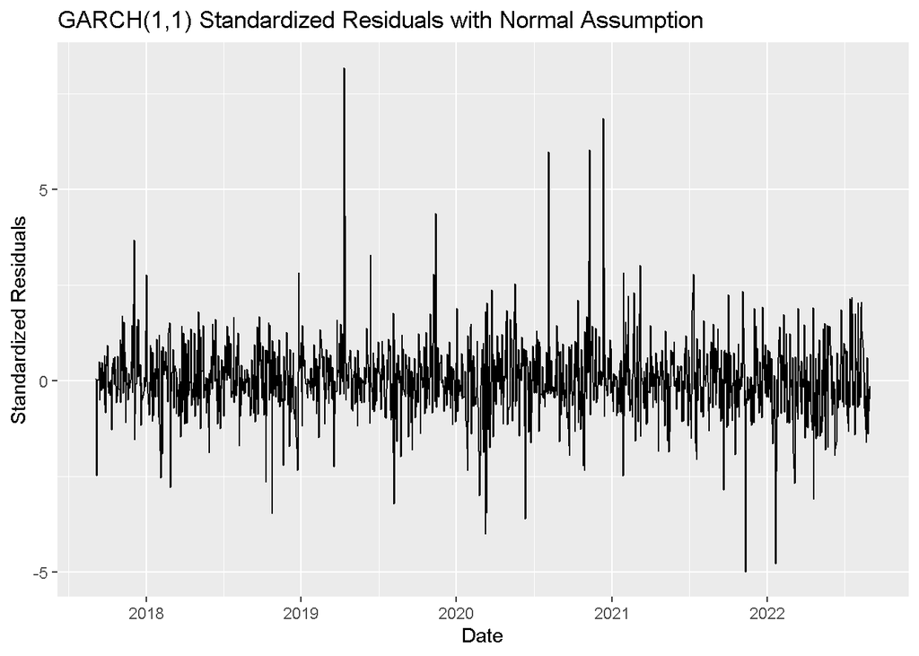

```r
# Estimated standardized residuals (innovations)
garch11_norm_sres = garch11_norm@residuals / garch11_norm_vol

# Estimated standardized residuals time plot
qplot(index(dis_lr), garch11_norm_sres, ylab="Standardized Residuals", xlab="Date", main="GARCH(1,1) Standardized Residuals with Normal Assumption", geom = "line")
```

From the histogram below, standardized residuals are slightly right-skewed, potentially due to outliers. A normal distribution curve doesn’t seem to trace the density bars very well as it underfits the peak.

The QQ plot shows that the left and right tails of the standardized residuals are heavier than those of a normal distribution, which suggests that both tails are not well-modeled by a normal distribution. This adds to the conclusion from the Jerque-Bera Test and histogram that standardized residuals are not normally distributed.

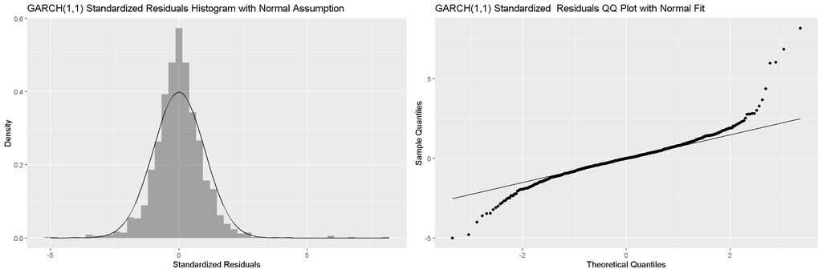

```r
# Histogram of standardized residuals
garch11_norm_sres_hist <- ggplot(as.data.frame(garch11_norm_sres), aes(x=garch11_norm_sres))+ geom_histogram(aes(y=..density..),alpha=0.5, bins = 50)+ labs(x='Standardized Residuals', y = 'Density', title="GARCH(1,1) Standardized Residuals Histogram with Normal Assumption")+ stat_function(fun = dnorm)

# QQ plot of standardized residuals
garch11_norm_sres_qq <- ggplot(as.data.frame(garch11_norm_sres), aes(sample=garch11_norm_sres))+ stat_qq(distribution = qnorm) + stat_qq_line(distribution = qnorm)+ labs(x="Theoretical Quantiles", y = "Sample Quantiles", title="GARCH(1,1) Standardized  Residuals QQ Plot with Normal Fit") # use ggplot to set the distribution fit

# Arrange histogram and qq plot side by side
grid.arrange(garch11_norm_sres_hist, garch11_norm_sres_qq, ncol=2)
```

The ACF plot suggests the standardized squared residuals to be significantly correlated at lag 23 at a 0.05 level. There are less than 2 significant autocorrelations so the standardized squared residuals are not correlated. This can also be verified via the LJung-Box Tests above. You may have observed already that the 0th lag of a series is the current time point and is always perfectly correlated with itself; that’s why the 0th lag autocorrelation is always 1. We used the `ggAcf()` function to omit the 0th lag autocorrelation and zoom in on the other lags.

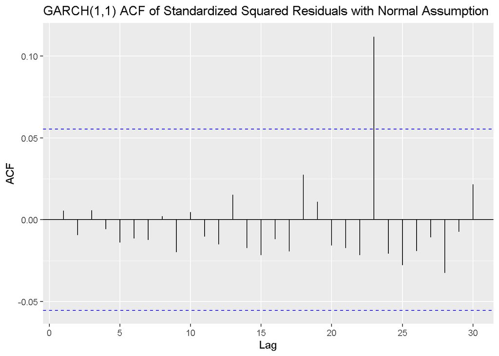

```r
ggAcf(garch11_norm_sres^2) + labs(title="GARCH(1,1) ACF of Standardized Squared Residuals with Normal Assumption")
```

### Try GARCH(1,1) with Student-t Innovations…

Let’s try fitting an GARCH(1,1) model with Student-t innovations. We obtain this model by setting `cond.dist = c("std")` to assume Student-t innovations and keeping the other `garchFit()` configurations to be the same.

From the Error Analysis, the p-values for the coefficient estimates, $\alpha_1$ and $\beta_1$ are < 0.05, meaning that $Y_{t-1}^2$ and $\sigma_{t-1}^2$ are significant in explaining model volatility.

From the Standardized Residuals Tests, Jarque-Bera Test and Shapiro-Wilk Test both have p-values < 0.05, indicating that the standardized residuals are not normally distributed. This makes sense because we assume Student-t innovations here. The first 3 Ljung Box Tests yield p-values > 0.05, implying that the standardized residuals are not correlated. The last 3 Ljung Box Tests yield p-values > 0.05, implying that the standardized squared residuals are not correlated.

From the Information Criterion Statistics, BIC = -5.454286, which is lower than what’s calculated for the GARCH(1,1) model with normal innovations. This indicates that GARCH(1,1) with Student-t innovations is a better-fitted model.

```r
# Try GARCH(1,1) model with Student-t innovations
garch11_std = garchFit(~garch(1,1), data= dis_lr,
cond.dist = c("std"), include.mean = FALSE,
algorithm = c("nlminb"), hessian = c("ropt"),
trace = FALSE)

# Model summary
summary(garch11_std)
```

```
##
## Title:
##  GARCH Modelling
##
## Call:
##  garchFit(formula = ~garch(1, 1), data = dis_lr, cond.dist = c("std"),
##     include.mean = FALSE, trace = FALSE, algorithm = c("nlminb"),
##     hessian = c("ropt"))
##
## Mean and Variance Equation:
##  data ~ garch(1, 1)
## <environment: 0x0000000026aaeaf8>
##  [data = dis_lr]
##
## Conditional Distribution:
##  std
##
## Coefficient(s):
##      omega      alpha1       beta1       shape
## 1.9333e-05  1.6338e-01  7.9993e-01  3.8645e+00
##
## Std. Errors:
##  based on Hessian
##
## Error Analysis:
##         Estimate  Std. Error  t value Pr(>|t|)
## omega  1.933e-05   6.554e-06    2.950  0.00318 **
## alpha1 1.634e-01   4.154e-02    3.933 8.38e-05 ***
## beta1  7.999e-01   4.373e-02   18.291  < 2e-16 ***
## shape  3.864e+00   4.358e-01    8.868  < 2e-16 ***
## ---
## Signif. codes:  0 '***' 0.001 '**' 0.01 '*' 0.05 '.' 0.1 ' ' 1
##
## Log Likelihood:
##  3442.292    normalized:  2.738498
##
## Description:
##  Mon Nov 21 01:42:52 2022 by user: user
##
##
## Standardised Residuals Tests:
##                                 Statistic p-Value
##  Jarque-Bera Test   R    Chi^2  7237.495  0
##  Shapiro-Wilk Test  R    W      0.9074602 0
##  Ljung-Box Test     R    Q(10)  4.182286  0.9387493
##  Ljung-Box Test     R    Q(15)  7.501771  0.9422032
##  Ljung-Box Test     R    Q(20)  13.74048  0.8434066
##  Ljung-Box Test     R^2  Q(10)  2.781151  0.9861155
##  Ljung-Box Test     R^2  Q(15)  4.162956  0.997153
##  Ljung-Box Test     R^2  Q(20)  5.481513  0.9994383
##  LM Arch Test       R    TR^2   3.64396   0.9890386
##
## Information Criterion Statistics:
##       AIC       BIC       SIC      HQIC
## -5.470631 -5.454286 -5.470652 -5.464488
```

We plot a time plot of the volatility estimates overlaying the log return series and observe that the volatility estimates don’t capture the swings with large magnitudes very well, especially especially from 2019 to 2021.

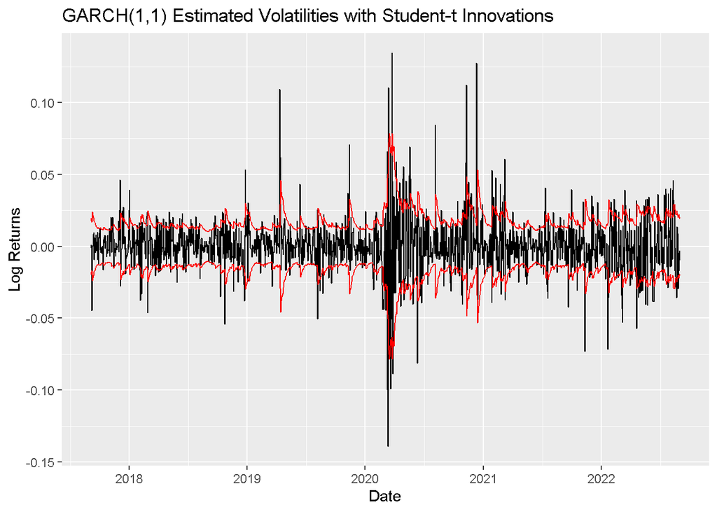

```r
# Estimated volatility values
garch11_std_vol = garch11_std@sigma.t

# Estimated volatility time plot
qplot(index(dis_lr), dis_lr, ylab="Log Returns", xlab="Date", main="GARCH(1,1) Estimated Volatilities with Student-t Innovations", geom = "line")+geom_line(data = as.data.frame(garch11_std_vol), aes(y=garch11_std_vol), color = "red")+geom_line(data = as.data.frame(-garch11_std_vol), aes(y=-garch11_std_vol), color = "red")
```

From the time plot of the standardized residuals, we see that the series is mean-reverting but has nonconstant variance. Therefore, the standardized residuals are nonstationary, and in turn, not a White Noise.

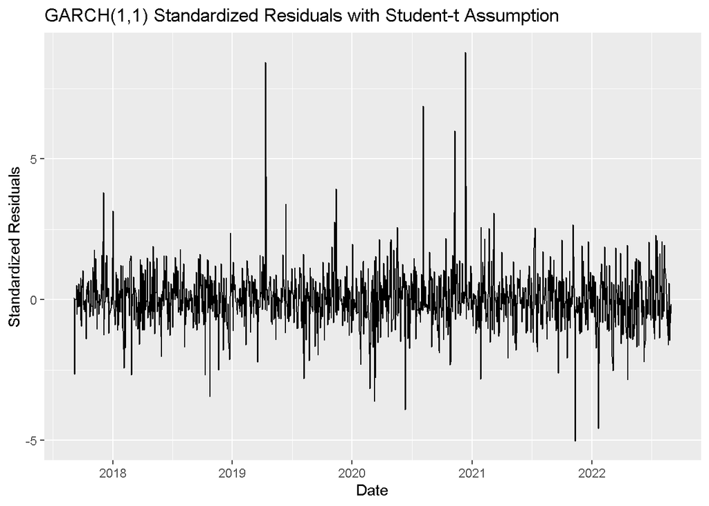

```r
# Estimated standardized residuals (innovations)
garch11_std_sres = garch11_std@residuals / garch11_std_vol

# Estimated standardized residuals time plot
qplot(index(dis_lr), garch11_std_sres, ylab="Standardized Residuals", xlab="Date", main="GARCH(1,1) Standardized Residuals with Student-t Assumption", geom = "line")
```

From the histogram below, standardized residuals are slightly right-skewed, potentially due to outliers. A Student-t distribution curve seems to trace the density bars fairly well because it traces the shape of the histogram closely.

The QQ plot shows that the right tail of the standardized residuals are heavier than that of a Student-t distribution. These extreme values may be what’s causing the outliers to appear in the histogram.

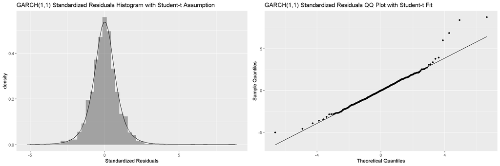

```r
# Estimate shape parameter of the model (needed for Student-t fit)
nu <- coef(garch11_std)[['shape']]

# Histogram of standardized residuals
garch11_std_sres_hist <- ggplot(as.data.frame(garch11_std_sres), aes(x=garch11_std_sres))+ geom_histogram(aes(y=..density..),alpha=0.5, bins = 50)+ labs(x='Standardized Residuals', title="GARCH(1,1) Standardized Residuals Histogram with Student-t Assumption")+ stat_function(fun = dstd, args = list(nu=nu))

# QQ plot of standardized residuals
garch11_std_sres_qq <- ggplot(as.data.frame(garch11_std_sres), aes(sample=garch11_std_sres))+ stat_qq(distribution = qstd, dparams=list(nu=nu)) + stat_qq_line(distribution = qstd, dparams=list(nu=nu))+ labs(x="Theoretical Quantiles", y = "Sample Quantiles", title="GARCH(1,1) Standardized Residuals QQ Plot with Student-t Fit") # use ggplot to set the distribution fit

# Arrange histogram and qq plot side by side
grid.arrange(garch11_std_sres_hist, garch11_std_sres_qq, ncol=2)
```

The ACF plot suggests the standardized squared residuals to be significantly correlated at lag 23 at a 0.05 level. There are less than 2 significant autocorrelations so the standardized squared residuals are not correlated.

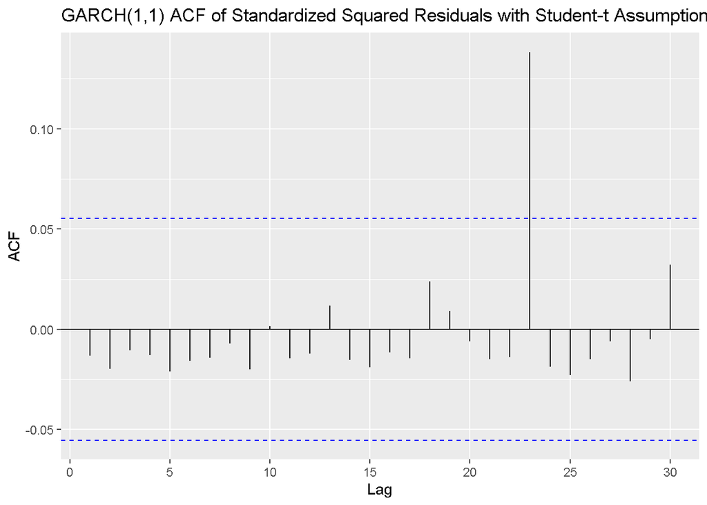

```r
ggAcf(garch11_std_sres^2) + labs(title="GARCH(1,1) ACF of Standardized Squared Residuals with Student-t Assumption")
```

### Try GARCH(1,1) with GED Innovations…

Let’s try fitting an GARCH(1,1) model with GED innovations. We obtain this model by setting `cond.dist = c("ged")` to assume GED innovations and keeping the other `garchFit()` configurations to be the same.

From the Error Analysis, the p-values for the coefficient estimates, $\alpha_1$ and $\beta_1$ are < 0.05, meaning that $Y_{t-1}^2$ and $\sigma_{t-1}^2$ are significant in explaining model volatility.

From the Standardized Residuals Tests, Jarque-Bera Test and Shapiro-Wilk Test both have p-values < 0.05, indicating that the standardized residuals are not normally distributed. This makes sense because we assume GED innovations here. The first 3 Ljung Box Tests yield p-values > 0.05, implying that the standardized residuals are not correlated. The last 3 Ljung Box Tests yield p-values > 0.05, implying that the standardized squared residuals are not correlated.

From the Information Criterion Statistics, BIC = -5.428917, which is higher than what’s calculated for the GARCH(1,1) model with Student-t innovations. This indicates that GARCH(1,1) with GED innovations doesn’t have the best goodness of fit.

```r
# Try GARCH(1,1) model with GED innovations
garch11_ged = garchFit(~garch(1,1), data= dis_lr,
cond.dist = c("ged"), include.mean = FALSE,
algorithm = c("nlminb"), hessian = c("ropt"),
trace = FALSE)

# Model summary
summary(garch11_ged)
```

```
##
## Title:
##  GARCH Modelling
##
## Call:
##  garchFit(formula = ~garch(1, 1), data = dis_lr, cond.dist = c("ged"),
##     include.mean = FALSE, trace = FALSE, algorithm = c("nlminb"),
##     hessian = c("ropt"))
##
## Mean and Variance Equation:
##  data ~ garch(1, 1)
## <environment: 0x00000000224a7ec0>
##  [data = dis_lr]
##
## Conditional Distribution:
##  ged
##
## Coefficient(s):
##      omega      alpha1       beta1       shape
## 1.6414e-05  1.2779e-01  8.2896e-01  1.0598e+00
##
## Std. Errors:
##  based on Hessian
##
## Error Analysis:
##         Estimate  Std. Error  t value Pr(>|t|)
## omega  1.641e-05   6.300e-06    2.606 0.009174 **
## alpha1 1.278e-01   3.473e-02    3.680 0.000233 ***
## beta1  8.290e-01   4.330e-02   19.145  < 2e-16 ***
## shape  1.060e+00   4.990e-02   21.239  < 2e-16 ***
## ---
## Signif. codes:  0 '***' 0.001 '**' 0.01 '*' 0.05 '.' 0.1 ' ' 1
##
## Log Likelihood:
##  3426.347    normalized:  2.725813
##
## Description:
##  Mon Nov 21 01:42:54 2022 by user: user
##
##
## Standardised Residuals Tests:
##                                 Statistic p-Value
##  Jarque-Bera Test   R    Chi^2  5896.111  0
##  Shapiro-Wilk Test  R    W      0.9127211 0
##  Ljung-Box Test     R    Q(10)  4.690423  0.910876
##  Ljung-Box Test     R    Q(15)  8.036929  0.9222936
##  Ljung-Box Test     R    Q(20)  14.11096  0.8248255
##  Ljung-Box Test     R^2  Q(10)  2.473284  0.9912593
##  Ljung-Box Test     R^2  Q(15)  4.002157  0.9977303
##  Ljung-Box Test     R^2  Q(20)  5.553431  0.9993801
##  LM Arch Test       R    TR^2   3.294942  0.9930792
##
## Information Criterion Statistics:
##       AIC       BIC       SIC      HQIC
## -5.445262 -5.428917 -5.445282 -5.439119
```

We plot a time plot of the volatility estimates overlaying the log return series and observe that the volatility estimates don’t capture the swings with large magnitudes very well, especially especially from 2019 to 2021.

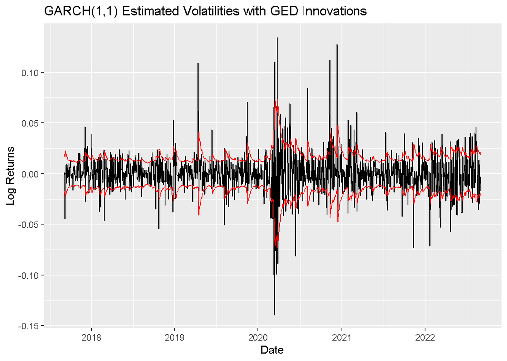

```r
# Estimated volatility values
garch11_ged_vol = garch11_ged@sigma.t

# Estimated volatility time plot
qplot(index(dis_lr), dis_lr, ylab="Log Returns", xlab="Date", main="GARCH(1,1) Estimated Volatilities with GED Innovations", geom = "line")+geom_line(data = as.data.frame(garch11_ged_vol), aes(y=garch11_ged_vol), color = "red")+geom_line(data = as.data.frame(-garch11_ged_vol), aes(y=-garch11_ged_vol), color = "red")
```

From the time plot of the standardized residuals, we see that the series is mean-reverting but has nonconstant variance. Therefore, the standardized residuals are nonstationary, and in turn, not a White Noise.

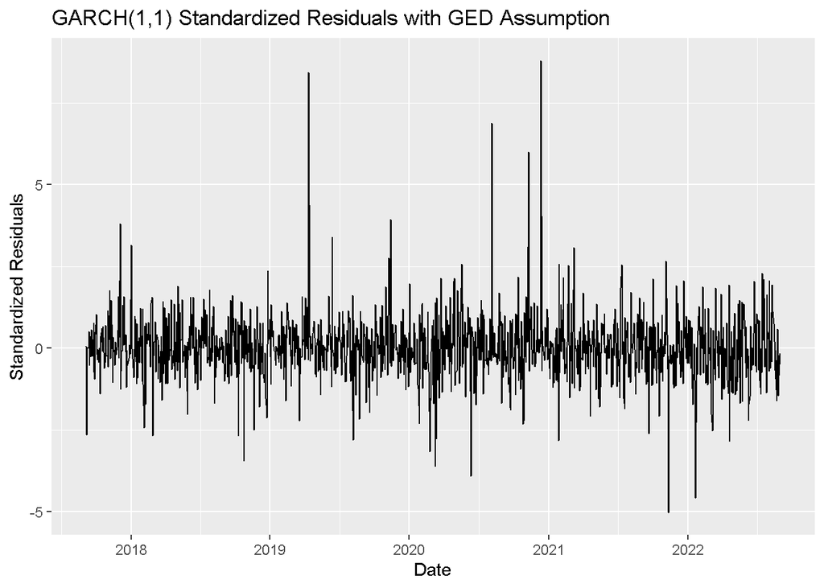

```r
# Estimated standardized residuals (innovations)
garch11_ged_sres = garch11_ged@residuals / garch11_std_vol

# Estimated standardized residuals time plot
qplot(index(dis_lr), garch11_ged_sres, ylab="Standardized Residuals", xlab="Date", main="GARCH(1,1) Standardized Residuals with GED Assumption", geom = "line")
```

From the histogram below, standardized residuals are slightly right-skewed, potentially due to outliers. A GED distribution curve doesn’t seem to trace the density bars very well as it overfits the peak.

The QQ plot shows that the left and right tails of the standardized residuals are lighter than those of a GED, which suggests that both tails are not well-modeled by a GED.

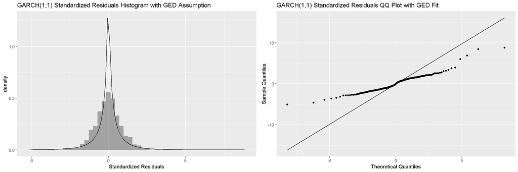

```r
# Estimate shape parameter of the model (needed for Student-t fit)
kappa = kurtosis(garch11_ged_sres, method = 'excess')[1]
nu_grid = seq(0.5, 2, 0.001) # generate possible values of nu
kappas = (gamma(5 / nu_grid) * gamma(1 / nu_grid) / gamma(3 / nu_grid^2))- 3 # possible values of kappa
nu= nu_grid[which.min(kappas > kappa)] # estimate of nu

# Histogram of standardized residuals
garch11_ged_sres_hist <- ggplot(as.data.frame(garch11_ged_sres), aes(x=garch11_ged_sres))+ geom_histogram(aes(y=..density..),alpha=0.5, bins = 50)+ labs(x='Standardized Residuals', title="GARCH(1,1) Standardized Residuals Histogram with GED Assumption")+ stat_function(fun = dged, args = list(nu=nu))

# QQ plot of standardized residuals
garch11_ged_sres_qq <- ggplot(as.data.frame(garch11_ged_sres), aes(sample=garch11_ged_sres))+ stat_qq(distribution = qged, dparams=list(nu=nu)) + stat_qq_line(distribution = qged, dparams=list(nu=nu))+ labs(x="Theoretical Quantiles", y = "Sample Quantiles", title="GARCH(1,1) Standardized Residuals QQ Plot with GED Fit") # use ggplot to set the distribution fit

# Arrange histogram and qq plot side by side
grid.arrange(garch11_ged_sres_hist, garch11_ged_sres_qq, ncol=2)
```

The ACF plot suggests the standardized squared residuals to be significantly correlated at lag 23 at a 0.05 level. There are less than 2 significant autocorrelations so the standardized squared residuals are not correlated.

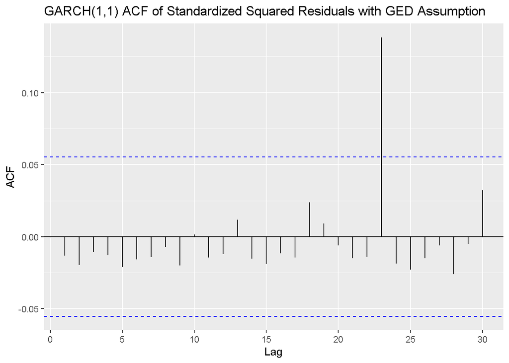

```r
ggAcf(garch11_ged_sres^2) + labs(title="GARCH(1,1) ACF of Standardized Squared Residuals with GED Assumption")
```

Out of the three models, GARCH(1,1) with Student-t innovations has the best BIC score, and its standardized residuals are most closely fitted using the Student-t distribution. We use this as our baseline model. Next, we will tune the p and q parameters in GARCH(p,q) to seek for any better-suited models, assuming Student-t innovations.

### Try Other GARCH(p,q) with Student-t Innovations…

We tune the p and q parameters in the GARCH(p,d) model, particularly, using `for` loops to iterate through different parameter combinations. We allow testing up to p = 4 and q = 4 as anything above that tends to complicate the model.

```r
# The range of GARCH p and q orders to test
p_param <- 1:4
q_param <- 1:4

# Create an empty data frame to store information criterion scores
GARCH_ICs <- data.frame("Model" = character(),
                        "AIC" = double(),
                        "BIC" = double())

# Populate the date frame
for (p in p_param){
  for (q in q_param){
    garch_std <- garchFit(substitute(~garch(sigma_p,arch_q), list(sigma_p=p, arch_q=q)), data = dis_lr, cond.dist = c("std"), include.mean = FALSE, algorithm = c("nlminb"), hessian = c("ropt"), trace = FALSE)
    GARCH_ICs[nrow(GARCH_ICs) + 1,] <- c(paste0('GARH(', p, ',', q, ')'), garch_std@fit$ics[1], garch_std@fit$ics[2])
  }
}

# Output score table, sorted by lowest to highest BIC
kable(GARCH_ICs[order(GARCH_ICs$BIC,decreasing=TRUE),], col.names = names(GARCH_ICs))
```

|  | Model | AIC | BIC |
| --- | --- | --- | --- |
| 1 | GARH(1,1) | -5.47063133591339 | -5.45428612283912 |
| 2 | GARH(1,2) | -5.46993769466482 | -5.44950617832197 |
| 5 | GARH(2,1) | -5.46897750088241 | -5.44854598453957 |
| 3 | GARH(1,3) | -5.46966833976518 | -5.44515052015377 |
| 6 | GARH(2,2) | -5.46834660467696 | -5.44382878506555 |
| 9 | GARH(3,1) | -5.46740651030538 | -5.44288869069397 |
| 4 | GARH(1,4) | -5.47043676122703 | -5.44183263834705 |
| 7 | GARH(2,3) | -5.46810272661538 | -5.4394986037354 |
| 13 | GARH(4,1) | -5.46794503006305 | -5.43934090718307 |
| 10 | GARH(3,2) | -5.46685184037355 | -5.43824771749357 |
| 8 | GARH(2,4) | -5.46884567125152 | -5.43615524510297 |
| 14 | GARH(4,2) | -5.46738125490639 | -5.43469082875784 |
| 11 | GARH(3,3) | -5.46651163665453 | -5.43382121050599 |
| 12 | GARH(3,4) | -5.46725458127111 | -5.43047785185399 |
| 15 | GARH(4,3) | -5.46702233704291 | -5.43024560762579 |
| 16 | GARH(4,4) | -5.46566349131142 | -5.42480045862574 |

We see that GARCH(1,1) with Student-t innovations has the lowest BIC score of -5.4543 and therefore is the best model to fit our log return series. We select the GARCH(1,1) as our forecasting model.

## Exercise #6: ARMA(p,q)-GARCH(p,q) on Disney’s Stock

An extension to GARCH(p) model is the ARMA(p,q)-GARCH(p,q) model, where residual correlations are captured and volatility clustering is accommodated. We will keep using the `garchFit()` function to configure the ARMA-GARCH models.

Since GARCH(1,1) with Student-t innovations is selected as the best model, we incorporate an ARMA component into this model by setting `~arma(p,q)+garch(1,1)`, and keep the other `garchFit()` configurations the same. We tune the p and q parameters in the ARMA(p,q) part of the ARMA(p,q)-GARCH(p,q) model, particularly, using `for` loops to iterate through different parameter combinations. We allow testing up to p = 4 and q = 4 as anything above that tends to complicate the model.

```r
# The range of ARMA p and q orders to test
p_param <- 0:4
q_param <- 0:4

# Create an empty data frame to store information criterion scores
ARMA_GARCH_ICs <- data.frame("Model" = character(),
                        "AIC" = double(),
                        "BIC" = double())

# Populate the date frame
for (p in p_param){
  for (q in q_param){
    arma_garch_std <- garchFit(substitute(~arma(arma_p, arma_q)+garch(1,1), list(arma_p=p, arma_q=q)), data = dis_lr, cond.dist = c("std"), include.mean = FALSE, algorithm = c("nlminb"), hessian = c("ropt"), trace = FALSE)
    ARMA_GARCH_ICs[nrow(ARMA_GARCH_ICs) + 1,] <- c(paste0('ARMA(', p, ',', q, ')-GARCH(1,1)'), arma_garch_std@fit$ics[1], arma_garch_std@fit$ics[2])
  }
}

# Output score table, sorted by BIC from lowest to highest
kable(ARMA_GARCH_ICs[order(ARMA_GARCH_ICs$AIC,decreasing=TRUE),], col.names = names(ARMA_GARCH_ICs))
```

|  | Model | AIC | BIC |
| --- | --- | --- | --- |
| 4 | ARMA(0,3)-GARCH(1,1) | -5.47737442573256 | -5.44877030285259 |
| 16 | ARMA(3,0)-GARCH(1,1) | -5.47737108371733 | -5.44876696083735 |
| 15 | ARMA(2,4)-GARCH(1,1) | -5.47637737688424 | -5.43551434419855 |
| 21 | ARMA(4,0)-GARCH(1,1) | -5.47583935443086 | -5.44314892828231 |
| 17 | ARMA(3,1)-GARCH(1,1) | -5.47581862923261 | -5.44312820308406 |
| 5 | ARMA(0,4)-GARCH(1,1) | -5.47579714849226 | -5.44310672234372 |
| 9 | ARMA(1,3)-GARCH(1,1) | -5.4757849425932 | -5.44309451644466 |
| 22 | ARMA(4,1)-GARCH(1,1) | -5.475618338029 | -5.43884160861189 |
| 20 | ARMA(3,4)-GARCH(1,1) | -5.47490723201989 | -5.42995789606564 |
| 10 | ARMA(1,4)-GARCH(1,1) | -5.47445860265441 | -5.4376818732373 |
| 18 | ARMA(3,2)-GARCH(1,1) | -5.47423059197257 | -5.43745386255546 |
| 14 | ARMA(2,3)-GARCH(1,1) | -5.47419459101126 | -5.43741786159414 |
| 23 | ARMA(4,2)-GARCH(1,1) | -5.47414404583236 | -5.43328101314668 |
| 25 | ARMA(4,4)-GARCH(1,1) | -5.4740262597134 | -5.42499062049058 |
| 19 | ARMA(3,3)-GARCH(1,1) | -5.47347747813197 | -5.43261444544628 |
| 24 | ARMA(4,3)-GARCH(1,1) | -5.47296017339079 | -5.42801083743654 |
| 7 | ARMA(1,1)-GARCH(1,1) | -5.47199454534404 | -5.44747672573263 |
| 2 | ARMA(0,1)-GARCH(1,1) | -5.47105071467952 | -5.45061919833668 |
| 6 | ARMA(1,0)-GARCH(1,1) | -5.47096572341111 | -5.45053420706827 |
| 8 | ARMA(1,2)-GARCH(1,1) | -5.47086202464819 | -5.44225790176822 |
| 12 | ARMA(2,1)-GARCH(1,1) | -5.4708608123069 | -5.44225668942692 |
| 1 | ARMA(0,0)-GARCH(1,1) | -5.47063133591339 | -5.45428612283912 |
| 3 | ARMA(0,2)-GARCH(1,1) | -5.46987678246562 | -5.44535896285421 |
| 11 | ARMA(2,0)-GARCH(1,1) | -5.46984653167839 | -5.44532871206698 |
| 13 | ARMA(2,2)-GARCH(1,1) | -5.46867419407378 | -5.43598376792523 |

We see that the pure GARCH(1,1) with Student-t innovations has the lowest BIC score of -5.4543 and therefore is the best model to fit our log return series. We select the pure GARCH(1,1) as our forecasting model.

However, this doesn’t mean that other models are not plausible. For instance, ARMA(0,1)-GARCH(1,1) can be used to account for 1-lag external market information. An example is that during COVID-19 in 2020, Disney gained a pervasive media coverage on the services it provided (e.g., Disney+), hence it is reasonable to incorporate such effect through the moving average part (q) of the ARMA(p,q) component in our model. In fact, this model aligns with reality closer if our perception of Disney here is correct.

From the model summary of ARMA(0,1)-GARCH(1,1), we observe a p-value = 0.11170 > 0.05 for $\epsilon_{t-1}$ in the ARMA model, meaning that it is insignificant to explaining the log returns. In this case, we would rather use the pure GARCH(1,1) which all the coefficients show significance.

```r
# Try ARMA(0,1)-GARCH(1,1) model with Student-t innovations
arma01garch11_std = garchFit(~arma(0,1)+garch(1,1), data= dis_lr,
cond.dist = c("std"), include.mean = FALSE,
algorithm = c("nlminb"), hessian = c("ropt"),
trace = FALSE)

# Model summary
summary(arma01garch11_std)
```

```
##
## Title:
##  GARCH Modelling
##
## Call:
##  garchFit(formula = ~arma(0, 1) + garch(1, 1), data = dis_lr,
##     cond.dist = c("std"), include.mean = FALSE, trace = FALSE,
##     algorithm = c("nlminb"), hessian = c("ropt"))
##
## Mean and Variance Equation:
##  data ~ arma(0, 1) + garch(1, 1)
## <environment: 0x0000000025ca8298>
##  [data = dis_lr]
##
## Conditional Distribution:
##  std
##
## Coefficient(s):
##         ma1        omega       alpha1        beta1        shape
## -4.6247e-02   1.9321e-05   1.6398e-01   7.9985e-01   3.8445e+00
##
## Std. Errors:
##  based on Hessian
##
## Error Analysis:
##          Estimate  Std. Error  t value Pr(>|t|)
## ma1    -4.625e-02   2.908e-02   -1.591  0.11170
## omega   1.932e-05   6.486e-06    2.979  0.00289 **
## alpha1  1.640e-01   4.155e-02    3.947 7.93e-05 ***
## beta1   7.998e-01   4.328e-02   18.480  < 2e-16 ***
## shape   3.844e+00   4.305e-01    8.931  < 2e-16 ***
## ---
## Signif. codes:  0 '***' 0.001 '**' 0.01 '*' 0.05 '.' 0.1 ' ' 1
##
## Log Likelihood:
##  3443.555    normalized:  2.739503
##
## Description:
##  Mon Nov 21 01:43:13 2022 by user: user
##
##
## Standardised Residuals Tests:
##                                 Statistic p-Value
##  Jarque-Bera Test   R    Chi^2  7156.858  0
##  Shapiro-Wilk Test  R    W      0.9071102 0
##  Ljung-Box Test     R    Q(10)  5.357255  0.866072
##  Ljung-Box Test     R    Q(15)  8.86182   0.8846309
##  Ljung-Box Test     R    Q(20)  15.36002  0.75545
##  Ljung-Box Test     R^2  Q(10)  2.7725    0.9862825
##  Ljung-Box Test     R^2  Q(15)  4.177445  0.997096
##  Ljung-Box Test     R^2  Q(20)  5.512034  0.9994142
##  LM Arch Test       R    TR^2   3.632169  0.9891973
##
## Information Criterion Statistics:
##       AIC       BIC       SIC      HQIC
## -5.471051 -5.450619 -5.471082 -5.463372
```

ARMA(1,0)-GARCH(1,1) can be also be used to account for 1-lag log return. During the course of the pandemic, log returns of a few consecutive days can cluster, and hence depend on their past values, hence it is reasonable to incorporate such effect through the autoregressive part (p) of the ARMA(p,q) component in our model. In fact, this model aligns with reality closer if our perception of Disney here is correct.

```r
# Try ARMA(1,0)-GARCH(1,1) model with Student-t innovations
arma10garch11_std = garchFit(~arma(1,0)+garch(1,1), data= dis_lr,
cond.dist = c("std"), include.mean = FALSE,
algorithm = c("nlminb"), hessian = c("ropt"),
trace = FALSE)

# Model summary
summary(arma10garch11_std)
```

```
##
## Title:
##  GARCH Modelling
##
## Call:
##  garchFit(formula = ~arma(1, 0) + garch(1, 1), data = dis_lr,
##     cond.dist = c("std"), include.mean = FALSE, trace = FALSE,
##     algorithm = c("nlminb"), hessian = c("ropt"))
##
## Mean and Variance Equation:
##  data ~ arma(1, 0) + garch(1, 1)
## <environment: 0x0000000027976e30>
##  [data = dis_lr]
##
## Conditional Distribution:
##  std
##
## Coefficient(s):
##         ar1        omega       alpha1        beta1        shape
## -4.4292e-02   1.9345e-05   1.6402e-01   7.9970e-01   3.8465e+00
##
## Std. Errors:
##  based on Hessian
##
## Error Analysis:
##          Estimate  Std. Error  t value Pr(>|t|)
## ar1    -4.429e-02   2.849e-02   -1.555  0.12005
## omega   1.934e-05   6.493e-06    2.979  0.00289 **
## alpha1  1.640e-01   4.156e-02    3.947 7.91e-05 ***
## beta1   7.997e-01   4.332e-02   18.462  < 2e-16 ***
## shape   3.847e+00   4.308e-01    8.928  < 2e-16 ***
## ---
## Signif. codes:  0 '***' 0.001 '**' 0.01 '*' 0.05 '.' 0.1 ' ' 1
##
## Log Likelihood:
##  3443.502    normalized:  2.739461
##
## Description:
##  Mon Nov 21 01:43:13 2022 by user: user
##
##
## Standardised Residuals Tests:
##                                 Statistic p-Value
##  Jarque-Bera Test   R    Chi^2  7159.192  0
##  Shapiro-Wilk Test  R    W      0.9071368 0
##  Ljung-Box Test     R    Q(10)  5.158822  0.880319
##  Ljung-Box Test     R    Q(15)  8.64291   0.8954364
##  Ljung-Box Test     R    Q(20)  15.13701  0.768515
##  Ljung-Box Test     R^2  Q(10)  2.775354  0.9862276
##  Ljung-Box Test     R^2  Q(15)  4.1786    0.9970914
##  Ljung-Box Test     R^2  Q(20)  5.515303  0.9994115
##  LM Arch Test       R    TR^2   3.63471   0.9891632
##
## Information Criterion Statistics:
##       AIC       BIC       SIC      HQIC
## -5.470966 -5.450534 -5.470997 -5.463287
```

For me, personally, I try to example simpler models first, models with p, q orders < 2. More complex models have higher risk of overfitting your data. If you are comforatable with this risk, you can examine the ARMA(0,3)-GARCH(1,1) and ARMA(3,0)-GARCH(1,1) models.

I will examine the ARMA(1,1)-GARCH(1,1) model here. This model can be used to account for 1-lag log return and external market information. For example, trading during earnings release dates can be very volatile because market returns tend to react to the earnings release; at the same time, there are some return information from the past can seep into the current return. This is a good time to incorporate such effect through both the autoregressive (p) and the moving average (q) parts of the ARMA(p,q) component in our model. In fact, this model aligns with reality closer if our perception of Disney here is correct.

From the Error Analysis, the p-values for the coefficient estimates are all < 0.05, meaning that $Y_{t-1}$, $\epsilon_{t-1}$, $Y_{t-1}^2$, and $\sigma_{t-1}^2$ are significant in explaining model volatility and log returns.

From the Standardized Residuals Tests, Jarque-Bera Test and Shapiro-Wilk Test both have p-values < 0.05, indicating that the standardized residuals are not normally distributed. This makes sense because we assume Student-t innovations here. The first 3 Ljung Box Tests yield p-values > 0.05, implying that the standardized residuals are not correlated. The last 3 Ljung Box Tests yield p-values > 0.05, implying that the standardized squared residuals are not correlated.

From the Information Criterion Statistics, BIC = -5.447477, which is ranked the 6th place among the ARMA(p,q)-GARCH(1,1) we tested. Whether to sacrifice model BIC for model reality strongly depends on your perception of the market at the time. I personally believe, at the time of writing, that both volatility clusters and external market information are important for explaining future stock movements.

```r
# Try ARMA(1,1)-GARCH(1,1) model with Student-t innovations
arma11garch11_std = garchFit(~arma(1,1)+garch(1,1), data= dis_lr,
cond.dist = c("std"), include.mean = FALSE,
algorithm = c("nlminb"), hessian = c("ropt"),
trace = FALSE)

# Model summary
summary(arma11garch11_std)
```

```
##
## Title:
##  GARCH Modelling
##
## Call:
##  garchFit(formula = ~arma(1, 1) + garch(1, 1), data = dis_lr,
##     cond.dist = c("std"), include.mean = FALSE, trace = FALSE,
##     algorithm = c("nlminb"), hessian = c("ropt"))
##
## Mean and Variance Equation:
##  data ~ arma(1, 1) + garch(1, 1)
## <environment: 0x0000000024d18e60>
##  [data = dis_lr]
##
## Conditional Distribution:
##  std
##
## Coefficient(s):
##         ar1          ma1        omega       alpha1        beta1        shape
##  8.2893e-01  -8.6518e-01   1.9533e-05   1.6735e-01   7.9788e-01   3.7819e+00
##
## Std. Errors:
##  based on Hessian
##
## Error Analysis:
##          Estimate  Std. Error  t value Pr(>|t|)
## ar1     8.289e-01   8.861e-02    9.355  < 2e-16 ***
## ma1    -8.652e-01   7.755e-02  -11.156  < 2e-16 ***
## omega   1.953e-05   6.522e-06    2.995  0.00274 **
## alpha1  1.673e-01   4.245e-02    3.942 8.07e-05 ***
## beta1   7.979e-01   4.338e-02   18.393  < 2e-16 ***
## shape   3.782e+00   4.223e-01    8.955  < 2e-16 ***
## ---
## Signif. codes:  0 '***' 0.001 '**' 0.01 '*' 0.05 '.' 0.1 ' ' 1
##
## Log Likelihood:
##  3445.149    normalized:  2.740771
##
## Description:
##  Mon Nov 21 01:43:13 2022 by user: user
##
##
## Standardised Residuals Tests:
##                                 Statistic p-Value
##  Jarque-Bera Test   R    Chi^2  7208.417  0
##  Shapiro-Wilk Test  R    W      0.9061478 0
##  Ljung-Box Test     R    Q(10)  9.638653  0.4727465
##  Ljung-Box Test     R    Q(15)  12.92606  0.6080093
##  Ljung-Box Test     R    Q(20)  19.18055  0.5101192
##  Ljung-Box Test     R^2  Q(10)  2.623564  0.9889501
##  Ljung-Box Test     R^2  Q(15)  4.051454  0.997564
##  Ljung-Box Test     R^2  Q(20)  5.336458  0.9995419
##  LM Arch Test       R    TR^2   3.453598  0.9914061
##
## Information Criterion Statistics:
##       AIC       BIC       SIC      HQIC
## -5.471995 -5.447477 -5.472040 -5.462780
```

We plot a time plot of the volatility estimates overlaying the log return series and observe that the volatility estimates still don’t capture the swings with large magnitudes very well, especially especially from 2019 to 2021.

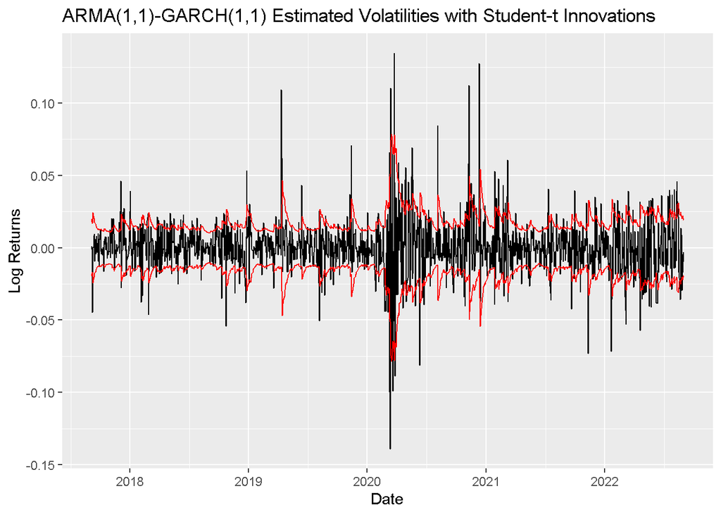

```r
# Estimated volatility values
arma11garch11_std_vol = arma11garch11_std@sigma.t

# Estimated volatility time plot
qplot(index(dis_lr), dis_lr, ylab="Log Returns", xlab="Date", main="ARMA(1,1)-GARCH(1,1) Estimated Volatilities with Student-t Innovations", geom = "line")+geom_line(data = as.data.frame(arma11garch11_std_vol), aes(y=arma11garch11_std_vol), color = "red")+geom_line(data = as.data.frame(-arma11garch11_std_vol), aes(y=-arma11garch11_std_vol), color = "red")
```

From the time plot of the standardized residuals, we see that the series is mean-reverting but has nonconstant variance. Therefore, the standardized residuals are nonstationary, and in turn, not a White Noise.

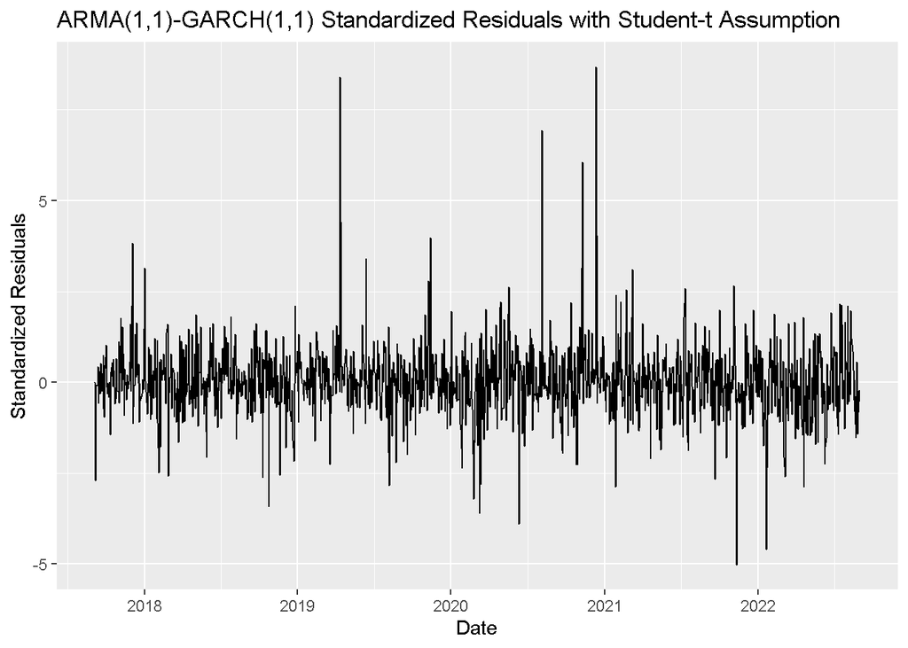

```r
# Estimated standardized residuals (innovations)
arma11garch11_std_sres = arma11garch11_std@residuals / arma11garch11_std_vol

# Estimated standardized residuals time plot
qplot(index(dis_lr), arma11garch11_std_sres, ylab="Standardized Residuals", xlab="Date", main="ARMA(1,1)-GARCH(1,1) Standardized Residuals with Student-t Assumption", geom = "line")
```

From the histogram below, standardized residuals are slightly right-skewed, potentially due to outliers. A Student-t distribution curve seems to trace the density bars fairly well because it traces the shape of the histogram closely.

The QQ plot shows that the right tail of the standardized residuals are heavier than that of a Student-t distribution. These extreme values may be what’s causing the outliers to appear in the histogram.

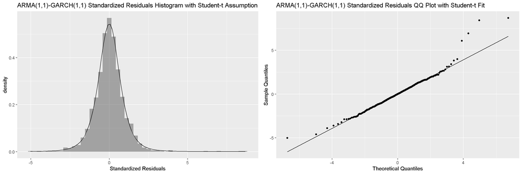

```r
# Estimate shape parameter of the model (needed for Student-t fit)
nu <- coef(arma11garch11_std)[['shape']]

# Histogram of standardized residuals
arma11garch11_std_sres_hist <- ggplot(as.data.frame(arma11garch11_std_sres), aes(x=arma11garch11_std_sres))+ geom_histogram(aes(y=..density..),alpha=0.5, bins = 50)+ labs(x='Standardized Residuals', title="ARMA(1,1)-GARCH(1,1) Standardized Residuals Histogram with Student-t Assumption")+ stat_function(fun = dstd, args = list(nu=nu))

# QQ plot of standardized residuals
arma11garch11_std_sres_qq <- ggplot(as.data.frame(arma11garch11_std_sres), aes(sample=arma11garch11_std_sres))+ stat_qq(distribution = qstd, dparams=list(nu=nu)) + stat_qq_line(distribution = qstd, dparams=list(nu=nu))+ labs(x="Theoretical Quantiles", y = "Sample Quantiles", title="ARMA(1,1)-GARCH(1,1) Standardized Residuals QQ Plot with Student-t Fit") # use ggplot to set the distribution fit

# Arrange histogram and qq plot side by side
grid.arrange(arma11garch11_std_sres_hist, arma11garch11_std_sres_qq, ncol=2)
```

The ACF plot suggests the standardized squared residuals to be significantly correlated at lag 23 at a 0.05 level. There are less than 2 significant autocorrelations so the standardized squared residuals are not correlated.

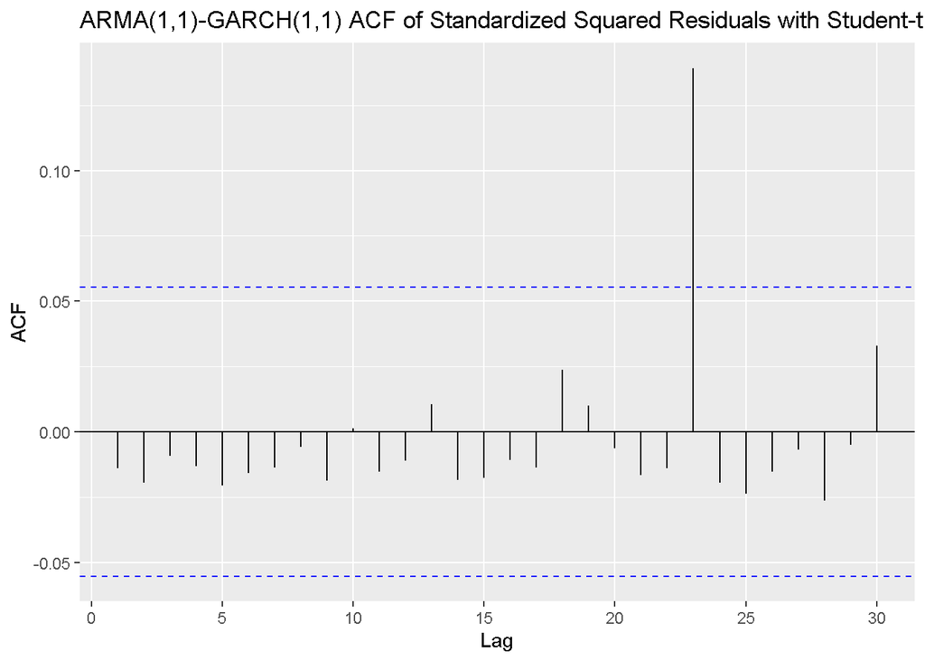

```r
ggAcf(arma11garch11_std_sres^2) + labs(title="ARMA(1,1)-GARCH(1,1) ACF of Standardized Squared Residuals with Student-t Assumption")
```

Out of the four models with Student-t innovations: GARCH(1,1), ARMA(0,1)-GARCH(1,1), ARMA(1,0)-GARCH(1,1), and ARMA(1,1)-GARCH(1,1), only GARCH(1,1) and ARMA(1,1)-GARCH(1,1) possess significant coefficient estimates. The volatility estimates and residual diagnostics between the two models are very similar. So, which model shall we use?

If you wouldn’t mind sacrificing a little BIC score for including your perception of reality into the model, then ARMA(1,1)-GARCH(1,1) would be a proper choice. This model is more flexible, and can catch more detailed patterns in a series. If you are a believer of the principle of parsimony, then GARCH(1,1) would be a proper choice. This model is simpler, and is easier to interpret. I belong to the prior group and will choose ARMA(1,1)-GARCH(1,1) as my forecasting model.

### ARMA(1,1)-GARCH(1,1) with Student-t Innovations Quarterly Forecast

From a 73-day ahead forecast, the slowing expansion at boundaries of the predicted series at a 5% significance level means that the volatility in the next quarter is predicted to increase at a progressively slower rate, with a 5% error.

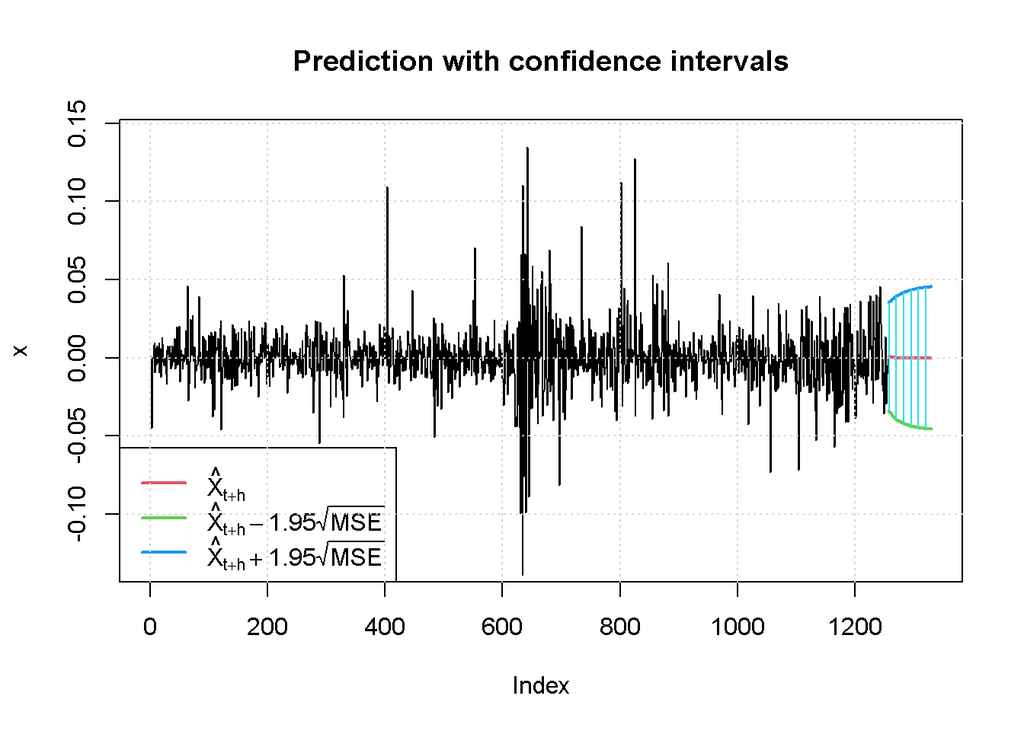

```r
# Number of days you want to forecast
h <- 73
# Output score table, sorted by BIC from lowest to highest
arma11garch11_std_forecast <- predict(arma11garch11_std, n.ahead = h, plot=TRUE, nx=length(dis_lr))
```

## Exercise #7: Relative Value-at-Risk (rVaR) and Relative Expected Shortfall (rES) of Disney’s Stock

To calculate the rVaR, we need to have an estimate of the distribution of the log returns in the next trading day. In the case of Student-t innovations, the mean and degrees of freedom estimate, $\hat{\mu}$ and $\hat{\nu}$, can be read off from the output of the `garchFit()` function. In order to estimate standard deviation or volatility, $\hat{\sigma}_{t+1}$, on that day, we can use the function `predict(arma11garch11_std, 1)` to find a one-day ahead prediction of volatility.

The rVaR for the Normal distribution, Student-t distribution, and GED at $\alpha$ significance levels are calculated using the following formulas:

- $rVaR_{Normal} = 1-e^{\hat{\mu}+\hat{\sigma_{t+1}}F_{Normal}^{-1}(\alpha)}$, where $F_{Normal}$ is the CDF of the Standard Normal distribution
- $rVaR_{Student-t} = 1-e^{\hat{\mu}+\hat{\sigma_{t+1}}\sqrt{\frac{\hat{\nu}-2}{\hat{\nu}}}F_{t_{\hat{\nu}}}^{-1}(\alpha)}$, where $F_{t_{\hat{\nu}}}$ is the CDF of the classical Student-t distribution on $\hat{\nu}$ degrees of freedom
- $rVaR_{GED} = 1-e^{\hat{\mu}+\hat{\sigma_{t+1}}F_{GED_{\hat{\nu}}}^{-1}(\alpha)}$, where $F_{GED_{\hat{\nu}}}$ is the CDF of the Generalized Error Distribution (GED) on $\hat{\nu}$ degrees of freedom

To calculate the rES, we first use Monte Carlo simulation to generate 10 million daily losses that assume the mean, degrees of freedom, and standard deviation estimates of the ARMA(1,1)-GARCH(1,1) model with Student-t innovations. Then, we find all the simulated losses that are above the rVaR value and then take their mean. **Since the simulation is randomized, we can expect a different but similar rES value on each run.**

```r
# Compute estimated volatility
arma11garch11_std_est <- predict(arma11garch11_std, n.ahead = 1)

# Mean forecast
arma11garch11_std_mu = arma11garch11_std_est$meanForecast

# Degrees of freedom forecast
arma11garch11_std_nu <- coef(arma11garch11_std)[['shape']]

# Standard deviation forecast
arma11garch11_std_sigma = arma11garch11_std_est$standardDeviation

# Create an empty data frame to store rVaR and rES results
risk_df <- data.frame("Significance.Level" = double(),
                        "rVaR" = double(),
                        "rES" = double())

# Probability of loss (significance level)
alpha_c = c(0.01, 0.05, 0.1)

# Number of Monte Carlo samples for generation
N=1e7

# Simulate 10 million losses based on Student-t estimates
arma11garch11_std_simLoss = -(exp(rstd(N, mean=arma11garch11_std_mu, sd=arma11garch11_std_sigma, nu = arma11garch11_std_nu))-1)

# For loop to populate risk table
for(a in alpha_c){
  # Calculate rVaR
  arma11garch11_std_rVaR = - (exp(arma11garch11_std_mu + arma11garch11_std_sigma * sqrt((arma11garch11_std_nu-2)/arma11garch11_std_nu) * qt(a, df = arma11garch11_std_nu)) - 1)
  # Calculate rES
  arma11garch11_std_rES = mean(arma11garch11_std_simLoss[arma11garch11_std_simLoss > arma11garch11_std_rVaR])
  # Populate risk table at each significance table
  risk_df[nrow(risk_df) + 1,] <- c(a, arma11garch11_std_rVaR, arma11garch11_std_rES)
}

# Output risk table
kable(risk_df, col.names = names(risk_df))
```

| Significance.Level | rVaR | rES |
| --- | --- | --- |
| 0.01 | 0.0450251 | 0.0632546 |
| 0.05 | 0.0250635 | 0.0383019 |
| 0.10 | 0.0177202 | 0.0296039 |